# Содержание

**ПРЕЗЕНТАЦИЯ И ДАШБОРД ссылки**

Презентация https://drive.google.com/file/d/1DV7-5HnCwMbN0_qEmRrpXWbXZRHnMYpt/view?usp=sharing

Дашборд https://public.tableau.com/app/profile/olga2478/viz/project_final_16523761025250/sheet4?publish=yes

# Проект:

# "Анализ поведения пользователей в мобильном приложении."

## Описание проекта.

**Заказчик:** менеджер мобильного приложения "Ненужные вещи"

Через приложение пользователи продают свои вещи, размещая их на доске объявлений.

**Задача:** Определить основные сценарии действий пользователей. Проанализировать связь целевого события - просмотра контактов - и других действий пользователя. Оценить, какие действия чаще совершают те пользователи, которые просматривают контакты. На основании этого исследования сделать выводы какие опции приложения работают лучше.

Для исследования представлены две таблицы с данными пользователей, впервые совершивших действия в приложении после 07.10.2019 года.

Таблица `mobile_sources.csv` содержит колонки:

- `userId` — идентификатор пользователя,
- `source` — источник, с которого пользователь установил приложение.

Колонки в `mobile_dataset.csv`:

- `event.time` — время совершения,
- `user.id` — идентификатор пользователя,
- `event.name` — действие пользователя.

Виды действий:

- `advert_open` — открыл карточки объявления,
- `photos_show` — просмотрел фотографий в объявлении,
- `tips_show` — увидел рекомендованные объявления,
- `tips_click` — кликнул по рекомендованному объявлению,
- `contacts_show` и `show_contacts` — посмотрел номер телефона,
- `contacts_call` — позвонил по номеру из объявления,
- `map` — открыл карту объявлений,
- `search_1` — `search_7` — разные действия, связанные с поиском по сайту,
- `favorites_add` — добавил объявление в избранное.

## Библиотеки и функции.

```python
import pandas as pd
import matplotlib.pyplot as plt
import seaborn as sns
import numpy as np
from datetime import datetime, timedelta
from scipy import stats as st
import math as mth
import warnings
warnings.filterwarnings('ignore')
```

**Функция для обзора датафрейма**

```python
# функция для обзора датафрейма
def df_overview(df):
    print('\nИнформация о таблице\n')
    df.info()
    print('\nПервые строки таблицы')
    display(df.head())
    if df.duplicated().sum()== 0:
        print('\nПолных дубликатов строк в таблице нет')
    else:
        print('\nКоличество полных дубликатов строк в таблице{}\n'.format(df.duplicated().sum()))
    n = 0
    for i in df.columns:
        if df[i].isna().sum() != 0:
            print('\nКоличество пропусков в столбце {} - {}'.format(i, df[i].isna().sum()))
            n += 1
    if n != 0:
        print('Всего пропущенные значения есть в {} столбцах'.format(n))
    else:
        print('В столбцах таблицы нет пропущенных значений')

    print('\nПервичная статистика по таблице')
    display(df.describe().T)
```

**Функция для расчета границ нормального распределения**

```python
# функция для расчета границ нормального распределения
def normal_borders(df, column):
    left_border=df[column].quantile(0.25)-1.5*(df[column].quantile(0.75)-df[column].quantile(0.25))
    right_border=df[column].quantile(0.75)+1.5*(df[column].quantile(0.75)-df[column].quantile(0.25))
    if left_border < 0:
        left_border = 0
    return left_border, right_border
```

**Функция для расчета удержания**

```python
def get_retention(
    profiles,
    sessions,
    observation_date,
    horizon_days,
    dimensions=[],
    ignore_horizon=False,
):

    # добавляем столбец payer в передаваемый dimensions список
    dimensions = ['event_target'] + dimensions

    # исключаем пользователей, не «доживших» до горизонта анализа
    last_suitable_acquisition_date = observation_date
    if not ignore_horizon:
        last_suitable_acquisition_date = observation_date - timedelta(
            days=horizon_days - 1
        )
    result_raw = profiles.query('dt <= @last_suitable_acquisition_date')

    # собираем «сырые» данные для расчёта удержания
    result_raw = result_raw.merge(
        sessions[['user_id', 'event_time']], on='user_id', how='left'
    )
    result_raw['lifetime'] = (
        result_raw['event_time'] - result_raw['first_ts']
    ).dt.days

    # функция для группировки таблицы по желаемым признакам
    def group_by_dimensions(df, dims, horizon_days):
        result = df.pivot_table(
            index=dims, columns='lifetime', values='user_id', aggfunc='nunique'
        )
        cohort_sizes = (
            df.groupby(dims)
            .agg({'user_id': 'nunique'})
            .rename(columns={'user_id': 'cohort_size'})
        )
        result = cohort_sizes.merge(result, on=dims, how='left').fillna(0)
        result = result.div(result['cohort_size'], axis=0)
        result = result[['cohort_size'] + list(range(horizon_days))]
        result['cohort_size'] = cohort_sizes
        return result

    # получаем таблицу удержания
    result_grouped = group_by_dimensions(result_raw, dimensions, horizon_days)

    # получаем таблицу динамики удержания
    result_in_time = group_by_dimensions(
        result_raw, dimensions + ['dt'], horizon_days
    )

    # возвращаем обе таблицы и сырые данные
    return result_raw, result_grouped, result_in_time
```

**Функция "сглаживания" графика**

```python
def filter_data(df, window):
    # для каждого столбца применяем скользящее среднее
    for column in df.columns.values:
        df[column] = df[column].rolling(window).mean()
    return df
```

**Функция для визуализации удержания**

```python
def plot_retention(retention, retention_history, horizon, window=7):

    # задаём размер сетки для графиков
    plt.figure(figsize=(15, 10))

    # исключаем размеры когорт и удержание первого дня
    retention = retention.drop(columns=['cohort_size', 0])
    # в таблице динамики оставляем только нужный лайфтайм
    retention_history = retention_history.drop(columns=['cohort_size'])[
        [horizon - 1]
    ]

    # если в индексах таблицы удержания только payer,
    # добавляем второй признак — cohort
    if retention.index.nlevels == 1:
        retention['cohort'] = 'All users'
        retention = retention.reset_index().set_index(['cohort', 'event_target'])

    # в таблице графиков — два столбца и две строки, четыре ячейки
    # в первой строим кривые удержания платящих пользователей
    ax1 = plt.subplot(2, 2, 1)
    retention.query('event_target == True').droplevel('event_target').T.plot(
        grid=True, ax=ax1
    )
    plt.legend()
    plt.xlabel('Лайфтайм')
    plt.title('Удержание совершивших\nцелевое действие пользователей')

    # во второй ячейке строим кривые удержания неплатящих
    # вертикальная ось — от графика из первой ячейки
    ax2 = plt.subplot(2, 2, 2, sharey=ax1)
    retention.query('event_target == False').droplevel('event_target').T.plot(
        grid=True, ax=ax2
    )
    plt.legend()
    plt.xlabel('Лайфтайм')
    plt.title('Удержание не совершивших\nцелевой действие пользователей')

    # в третьей ячейке — динамика удержания платящих
    ax3 = plt.subplot(2, 2, 3)
    # получаем названия столбцов для сводной таблицы
    columns = [
        name
        for name in retention_history.index.names
        if name not in ['dt', 'event_target']
    ]
    # фильтруем данные и строим график
    filtered_data = retention_history.query('event_target == True').pivot_table(
        index='dt', columns=columns, values=horizon - 1, aggfunc='mean'
    )
    filter_data(filtered_data, window).plot(grid=True, ax=ax3)
    plt.xlabel('Дата привлечения')
    plt.title(
        'Динамика удержания\nсовершивших целевое действие\nпользователей  на {}-й день'.format(
            horizon
        )
    )

    # в чётвертой ячейке — динамика удержания неплатящих
    ax4 = plt.subplot(2, 2, 4, sharey=ax3)
    # фильтруем данные и строим график
    filtered_data = retention_history.query('event_target == False').pivot_table(
        index='dt', columns=columns, values=horizon - 1, aggfunc='mean'
    )
    filter_data(filtered_data, window).plot(grid=True, ax=ax4)
    plt.xlabel('Дата привлечения')
    plt.title(
        'Динамика удержания\nне совершивших целевое действие\nпользователей на {}-й день'.format(
            horizon
        )
    )

    plt.tight_layout()
    plt.show()
```

**Функция для расчёта конверсии**

```python
# функция для расчёта конверсии

def get_conversion(
    profiles,
    purchases,
    observation_date,
    horizon_days,
    dimensions=[],
    ignore_horizon=False,
):

    # исключаем пользователей, не «доживших» до горизонта анализа
    last_suitable_acquisition_date = observation_date
    if not ignore_horizon:
        last_suitable_acquisition_date = observation_date - timedelta(
            days=horizon_days - 1
        )
    result_raw = profiles.query('dt <= @last_suitable_acquisition_date')

    # определяем дату и время первой покупки для каждого пользователя
    first_purchases = (
        purchases.sort_values(by=['user_id', 'event_date'])
        .groupby('user_id')
        .agg({'event_date': 'first'})
        .reset_index()
    )

    # добавляем данные о покупках в профили
    result_raw = result_raw.merge(
        first_purchases[['user_id', 'event_date']], on='user_id', how='left'
    )

    # рассчитываем лайфтайм для каждой покупки
    result_raw['lifetime'] = (
        result_raw['event_date'] - result_raw['first_ts']
    ).dt.days

    # группируем по cohort, если в dimensions ничего нет
    if len(dimensions) == 0:
        result_raw['cohort'] = 'All users'
        dimensions = dimensions + ['cohort']

    # функция для группировки таблицы по желаемым признакам
    def group_by_dimensions(df, dims, horizon_days):
        result = df.pivot_table(
            index=dims, columns='lifetime', values='user_id', aggfunc='nunique'
        )
        result = result.fillna(0).cumsum(axis = 1)
        cohort_sizes = (
            df.groupby(dims)
            .agg({'user_id': 'nunique'})
            .rename(columns={'user_id': 'cohort_size'})
        )
        result = cohort_sizes.merge(result, on=dims, how='left').fillna(0)
        # делим каждую «ячейку» в строке на размер когорты
        # и получаем conversion rate
        result = result.div(result['cohort_size'], axis=0)
        result = result[['cohort_size'] + list(range(horizon_days))]
        result['cohort_size'] = cohort_sizes
        return result

    # получаем таблицу конверсии
    result_grouped = group_by_dimensions(result_raw, dimensions, horizon_days)

    # для таблицы динамики конверсии убираем 'cohort' из dimensions
    if 'cohort' in dimensions:
        dimensions = []

    # получаем таблицу динамики конверсии
    result_in_time = group_by_dimensions(
        result_raw, dimensions + ['dt'], horizon_days
    )

    # возвращаем обе таблицы и сырые данные
    return result_raw, result_grouped, result_in_time
```

**Функция для визуализации конверсии**

```python
def plot_conversion(conversion, conversion_history, horizon, window=7):

    # задаём размер сетки для графиков
    plt.figure(figsize=(15, 5))

    # исключаем размеры когорт
    conversion = conversion.drop(columns=['cohort_size'])
    # в таблице динамики оставляем только нужный лайфтайм
    conversion_history = conversion_history.drop(columns=['cohort_size'])[
        [horizon - 1]
    ]

    # первый график — кривые конверсии
    ax1 = plt.subplot(1, 2, 1)
    conversion.T.plot(grid=True, ax=ax1)
    plt.legend()
    plt.xlabel('Лайфтайм')
    plt.title('Конверсия пользователей')

    # второй график — динамика конверсии
    ax2 = plt.subplot(1, 2, 2, sharey=ax1)
    columns = [
        # столбцами сводной таблицы станут все столбцы индекса, кроме даты
        name for name in conversion_history.index.names if name not in ['dt']
    ]
    filtered_data = conversion_history.pivot_table(
        index='dt', columns=columns, values=horizon - 1, aggfunc='mean'
    )
    filter_data(filtered_data, window).plot(grid=True, ax=ax2)
    plt.xlabel('Дата привлечения')
    plt.title('Динамика конверсии пользователей на {}-й день'.format(horizon))

    plt.tight_layout()
    plt.show()
```

**Функция для проверки гипотез z-тестом**

```python
def check_hypothesise(successes1, successes2, trials1, trials2):
    p1 = successes1 / trials1
    p2 = successes2 / trials2
    p_combined = (successes1 + successes2) / (trials1 + trials2)
    difference = p1 - p2
    z_value = difference / mth.sqrt(p_combined * (1 - p_combined) * (1/trials1 + 1/trials2))
    distr = st.norm(0, 1)
    p_value = (1 - distr.cdf(abs(z_value))) * 2
    return p_value
```

## Обзор данных

Загрузим таблицы с данными.

```python
df_sources = pd.read_csv('mobile_soures.csv')
df_events = pd.read_csv('mobile_dataset.csv')
```

**Обзор таблицы `df_sources` с уникальными пользователями и источниками**

```python
df_overview(df_sources)
```

```
Информация о таблице

<class 'pandas.core.frame.DataFrame'>
RangeIndex: 4293 entries, 0 to 4292
Data columns (total 2 columns):
 #   Column  Non-Null Count  Dtype
---  ------  --------------  -----
 0   userId  4293 non-null   object
 1   source  4293 non-null   object
dtypes: object(2)
memory usage: 67.2+ KB

Первые строки таблицы
```

|  | userId | source |
| --- | --- | --- |
| 0 | 020292ab-89bc-4156-9acf-68bc2783f894 | other |
| 1 | cf7eda61-9349-469f-ac27-e5b6f5ec475c | yandex |
| 2 | 8c356c42-3ba9-4cb6-80b8-3f868d0192c3 | yandex |
| 3 | d9b06b47-0f36-419b-bbb0-3533e582a6cb | other |
| 4 | f32e1e2a-3027-4693-b793-b7b3ff274439 | google |

```
Полных дубликатов строк в таблице нет
В столбцах таблицы нет пропущенных значений

Первичная статистика по таблице
```

|  | count | unique | top | freq |
| --- | --- | --- | --- | --- |
| userId | 4293 | 4293 | 3f3b2abf-f9fa-40fc-9319-3578ed857391 | 1 |
| source | 4293 | 3 | yandex | 1934 |

Всего нам предоставили данные о 4293 уникальных пользователях. Пользователи устанавливают приложение из 3-х источников, самый популярный `yandex`

Что можно исправить:

1. Привести название столбца `userId` к хорошему стилю.

```python
df_sources = df_sources.rename(columns={'userId': 'user_id'})
df_sources.columns
```

```
Index(['user_id', 'source'], dtype='object')
```

**Обзор таблицы `df_events` с событиями**

```python
df_overview(df_events)
```

```
Информация о таблице

<class 'pandas.core.frame.DataFrame'>
RangeIndex: 74197 entries, 0 to 74196
Data columns (total 3 columns):
 #   Column      Non-Null Count  Dtype
---  ------      --------------  -----
 0   event.time  74197 non-null  object
 1   event.name  74197 non-null  object
 2   user.id     74197 non-null  object
dtypes: object(3)
memory usage: 1.7+ MB

Первые строки таблицы
```

|  | event.time | event.name | user.id |
| --- | --- | --- | --- |
| 0 | 2019-10-07 00:00:00.431357 | advert_open | 020292ab-89bc-4156-9acf-68bc2783f894 |
| 1 | 2019-10-07 00:00:01.236320 | tips_show | 020292ab-89bc-4156-9acf-68bc2783f894 |
| 2 | 2019-10-07 00:00:02.245341 | tips_show | cf7eda61-9349-469f-ac27-e5b6f5ec475c |
| 3 | 2019-10-07 00:00:07.039334 | tips_show | 020292ab-89bc-4156-9acf-68bc2783f894 |
| 4 | 2019-10-07 00:00:56.319813 | advert_open | cf7eda61-9349-469f-ac27-e5b6f5ec475c |

```
Полных дубликатов строк в таблице нет
В столбцах таблицы нет пропущенных значений

Первичная статистика по таблице
```

|  | count | unique | top | freq |
| --- | --- | --- | --- | --- |
| event.time | 74197 | 74197 | 2019-10-30 14:55:49.720400 | 1 |
| event.name | 74197 | 16 | tips_show | 40055 |
| user.id | 74197 | 4293 | cb36854f-570a-41f4-baa8-36680b396370 | 478 |

В таблице содержатся данные о 74197 событиях.

Kоличество уникальных пользователей совпадает с данными первой таблицы - 4293.

Количество уникальных событий - 16 (соответствует описанию)

Самое популярное событие `tips_show`

Максимальное количество событий, совершеных одним пользователем 478.

Что можно исправить:

1. Убрать точки из названия столбцов
2. Столбец `event.time` привести к фомату `datetime`
3. В столбеце `event.name` устранить неявные дубликаты, указанные в описании (`contacts_show` и `show_contacts`)
4. Объединить события `search_1` — `search_7` в одно (это все шаги поиска, отдельного описания на каждый из них нет).

Исправим названия столбцов

```python
df_events.columns = df_events.columns.str.replace('.', '_')
df_events.columns
```

```
Index(['event_time', 'event_name', 'user_id'], dtype='object')
```

Приведем столбец `event_time` к нужному формату

```python
df_events['event_time'] = pd.to_datetime (df_events['event_time'])
df_events.info()
```

```
<class 'pandas.core.frame.DataFrame'>
RangeIndex: 74197 entries, 0 to 74196
Data columns (total 3 columns):
 #   Column      Non-Null Count  Dtype
---  ------      --------------  -----
 0   event_time  74197 non-null  datetime64[ns]
 1   event_name  74197 non-null  object
 2   user_id     74197 non-null  object
dtypes: datetime64[ns](1), object(2)
memory usage: 1.7+ MB
```

Посмотрим названия событий в `event_name` и устраним неявные дубликаты

```python
df_events['event_name'].sort_values().unique()
```

```
array(['advert_open', 'contacts_call', 'contacts_show', 'favorites_add',
       'map', 'photos_show', 'search_1', 'search_2', 'search_3',
       'search_4', 'search_5', 'search_6', 'search_7', 'show_contacts',
       'tips_click', 'tips_show'], dtype=object)
```

```python
df_events.loc[df_events['event_name'] == 'show_contacts', 'event_name'] = 'contacts_show'
```

```python
searches = [
    'search_1',
    'search_2',
    'search_3',
    'search_4',
    'search_5',
    'search_6',
    'search_7'
]

for search in searches:
    df_events.loc[df_events['event_name'] == search, 'event_name'] = 'search_1-7'

df_events['event_name'].sort_values().unique()
```

```
array(['advert_open', 'contacts_call', 'contacts_show', 'favorites_add',
       'map', 'photos_show', 'search_1-7', 'tips_click', 'tips_show'],
      dtype=object)
```

**Вывод**

Для исследования нам предоставлены данные с уникальными идентификаторами пользователей и источниками загрузки приложения, а также данные о событиях, совершенных пользователями в приложении.

Данные выгружены в таблицы `df_sources` и `df_events` соответственно.

Объем данных в таблице `df_sources` - 67.2+ KB (содержит 2 столбца и 4293 строки) Объем данных в ттаблице `df_events` - 1.7+ MB (содержит 3 столбца и 74197 строк)

В ходе предобработки были обнаружены следующие проблемы с данными:

- нарушения в стиле заголовков (названия столбцов записаны с использованием двух регистров и содержали точки),
- несоответствие типов данных - данные содержащие дату, сохранены в формате `object`,
- неявные дубликаты названий событий - `show_contacts` и `contacts_show` в таблице `df_events`.

Названия столбцов привели к "хорошему стилю" . Столбцы, содержащие дату привели к формату `datetime`, устранили неявные дубликаты. Также, для удобства, объединили события, относящиеся к поиску на сайте `search_1` - `search_7` в одно `search_1-7`.

Можно сказать, что таблицы содержат корректные данные и готовы к дальнейшему анализу.

## Исследовательский анализ

### Подготовка данных.

Добавим к таблицам столбцы с данными, необходимыми для дальнейшего иссоедования и расчета конверсии и удержания.

**Профили пользователей**

Создадим таблицу с профилями пользователей. Добавим к таблице `df_sources` данные о первом посещении, и совершении целевого действия пользователем

```python
first_visit = (
    df_events.sort_values(by=['user_id', 'event_time'])
    .groupby('user_id')
    .agg({'event_time': 'first'})
    .rename(columns={'event_time': 'first_ts'})
    .reset_index()
)
profiles = df_sources.merge(first_visit, on='user_id', how='left')
profiles['dt'] = profiles['first_ts'].dt.date
profiles['month'] = profiles['first_ts'].astype('datetime64[M]')


profiles['event_target'] =(
    profiles['user_id'].isin(df_events.query('event_name == "contacts_show"')['user_id'].unique())
)
profiles.head()
```

|  | user_id | source | first_ts | dt | month | event_target |
| --- | --- | --- | --- | --- | --- | --- |
| 0 | 020292ab-89bc-4156-9acf-68bc2783f894 | other | 2019-10-07 00:00:00.431357 | 2019-10-07 | 2019-10-01 | False |
| 1 | cf7eda61-9349-469f-ac27-e5b6f5ec475c | yandex | 2019-10-07 00:00:02.245341 | 2019-10-07 | 2019-10-01 | False |
| 2 | 8c356c42-3ba9-4cb6-80b8-3f868d0192c3 | yandex | 2019-10-07 00:02:07.374346 | 2019-10-07 | 2019-10-01 | True |
| 3 | d9b06b47-0f36-419b-bbb0-3533e582a6cb | other | 2019-10-07 00:05:20.190956 | 2019-10-07 | 2019-10-01 | False |
| 4 | f32e1e2a-3027-4693-b793-b7b3ff274439 | google | 2019-10-07 00:09:33.715659 | 2019-10-07 | 2019-10-01 | False |

**Добавим данные для проверки гипотез**

- пользователь совершал только шаг `tips_show`,
- пользователь совершал шаги `tips_click` и `tips_show`,
- пользователь совершал шаг `photos_show`

```python
users_tips_show = df_events.query('event_name == "tips_show"')['user_id'].unique()
users_tips_click = df_events.query('event_name == "tips_click"')['user_id'].unique()
users_photos_show = df_events.query('event_name == "photos_show"')['user_id'].unique()
profiles['event_tips'] = 'no_event'
profiles.loc[profiles['user_id'].isin(users_tips_show), 'event_tips'] = 'tips_show'
profiles.loc[
    (profiles['user_id'].isin(users_tips_show) & profiles['user_id'].isin(users_tips_click)), 'event_tips'
] = 'tips_show_and_click'

profiles['event_photos'] = 'no_event'
profiles.loc[profiles['user_id'].isin(users_photos_show), 'event_photos'] = 'photos_show'

profiles.head()
```

|  | user_id | source | first_ts | dt | month | event_target | event_tips | event_photos |
| --- | --- | --- | --- | --- | --- | --- | --- | --- |
| 0 | 020292ab-89bc-4156-9acf-68bc2783f894 | other | 2019-10-07 00:00:00.431357 | 2019-10-07 | 2019-10-01 | False | tips_show | no_event |
| 1 | cf7eda61-9349-469f-ac27-e5b6f5ec475c | yandex | 2019-10-07 00:00:02.245341 | 2019-10-07 | 2019-10-01 | False | tips_show_and_click | no_event |
| 2 | 8c356c42-3ba9-4cb6-80b8-3f868d0192c3 | yandex | 2019-10-07 00:02:07.374346 | 2019-10-07 | 2019-10-01 | True | tips_show_and_click | no_event |
| 3 | d9b06b47-0f36-419b-bbb0-3533e582a6cb | other | 2019-10-07 00:05:20.190956 | 2019-10-07 | 2019-10-01 | False | tips_show | no_event |
| 4 | f32e1e2a-3027-4693-b793-b7b3ff274439 | google | 2019-10-07 00:09:33.715659 | 2019-10-07 | 2019-10-01 | False | tips_show | no_event |

**Журнал сессий**

Добавим к таблице с событиями колонки с датой, днем недели и номером недели.

```python
df_events['event_date'] = df_events['event_time'].dt.date
df_events['event_weekday'] = df_events['event_time'].dt.weekday
df_events['event_week'] = df_events['event_time'].dt.week
```

```python
df_events.head()
```

|  | event_time | event_name | user_id | event_date | event_weekday | event_week |
| --- | --- | --- | --- | --- | --- | --- |
| 0 | 2019-10-07 00:00:00.431357 | advert_open | 020292ab-89bc-4156-9acf-68bc2783f894 | 2019-10-07 | 0 | 41 |
| 1 | 2019-10-07 00:00:01.236320 | tips_show | 020292ab-89bc-4156-9acf-68bc2783f894 | 2019-10-07 | 0 | 41 |
| 2 | 2019-10-07 00:00:02.245341 | tips_show | cf7eda61-9349-469f-ac27-e5b6f5ec475c | 2019-10-07 | 0 | 41 |
| 3 | 2019-10-07 00:00:07.039334 | tips_show | 020292ab-89bc-4156-9acf-68bc2783f894 | 2019-10-07 | 0 | 41 |
| 4 | 2019-10-07 00:00:56.319813 | advert_open | cf7eda61-9349-469f-ac27-e5b6f5ec475c | 2019-10-07 | 0 | 41 |

**Разделим события на сессии.**

В логе событий нет информации о начале и конце пользовательской сессии, чтобы разделить события на сессии сначала посмотрим сколько времени пользователи проводят в приложении в течении дня.

```python
avg_time_per_day = (
    df_events.sort_values(by=['event_time'])
    .groupby(['event_date', 'user_id'], sort=False)
    .agg({'event_time':['first', 'last']})
    .droplevel(1, axis=1)
    .reset_index()
)
avg_time_per_day.columns = ['date', 'user_id', 'first_time', 'last_time']
#avg_time_per_day.head()
avg_time_per_day['time_minutes'] =(
    (avg_time_per_day['last_time'] - avg_time_per_day['first_time'])
    .astype('timedelta64[m]')
)
avg_time_per_day.head()
```

|  | date | user_id | first_time | last_time | time_minutes |
| --- | --- | --- | --- | --- | --- |
| 0 | 2019-10-07 | 020292ab-89bc-4156-9acf-68bc2783f894 | 2019-10-07 00:00:00.431357 | 2019-10-07 00:18:42.917148 | 18.0 |
| 1 | 2019-10-07 | cf7eda61-9349-469f-ac27-e5b6f5ec475c | 2019-10-07 00:00:02.245341 | 2019-10-07 00:41:40.115094 | 41.0 |
| 2 | 2019-10-07 | 8c356c42-3ba9-4cb6-80b8-3f868d0192c3 | 2019-10-07 00:02:07.374346 | 2019-10-07 00:30:22.373280 | 28.0 |
| 3 | 2019-10-07 | d9b06b47-0f36-419b-bbb0-3533e582a6cb | 2019-10-07 00:05:20.190956 | 2019-10-07 00:05:23.427766 | 0.0 |
| 4 | 2019-10-07 | f32e1e2a-3027-4693-b793-b7b3ff274439 | 2019-10-07 00:09:33.715659 | 2019-10-07 00:50:22.211720 | 40.0 |

```python
print(
    f'Минимальное время, которое пользователи проводят в приложении в день',
    avg_time_per_day['time_minutes'].min()
)
print(
    '\nМаксимальное время, проведенное пользователем в приложении в день',
    avg_time_per_day['time_minutes'].max()
)
print(
    '\nСреднее время, которое пользователи проводят в приложении в день',
    avg_time_per_day['time_minutes'].mean()
)
print(
    ' \nМедианное время, которое пользователи проводят в приложении в день',
    avg_time_per_day['time_minutes'].median()
)
```

```
Минимальное время, которое пользователи проводят в приложении в день 0.0

Максимальное время, проведенное пользователем в приложении в день 1417.0

Среднее время, которое пользователи проводят в приложении в день 82.60035819368044

Медианное время, которое пользователи проводят в приложении в день 11.0
```

Как видно среднее значение в 7 раз больше медианного из-за пользователей, которые проводят в приложении значительно больше времени, чем большинство.

Посмотрим на распределение времени в пределах нормальных значеней Для их расчета применим функцию `normal_borders`

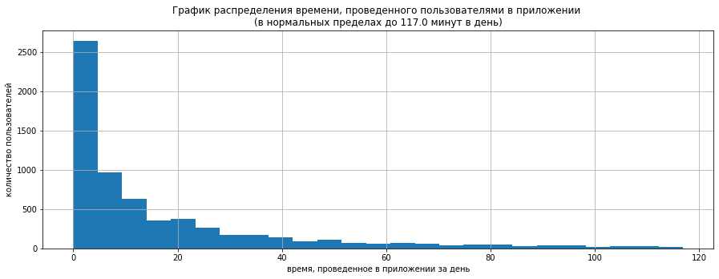

```python
a_border, b_border = normal_borders(avg_time_per_day, 'time_minutes')

avg_time_per_day['time_minutes'].hist(range=(a_border, b_border), bins=25, figsize=(15,5),)
plt.title(
    'График распределения времени, проведенного пользователями в приложении \n(в нормальных пределах до {} минут в день)'
    .format(b_border)
)
plt.ylabel('количество пользователей')
plt.xlabel('время, проведенное в приложении за день')
plt.show()
```

В целом основная часть пользователей проводит в приложении менее 20 минут в день. Более 2600 пользователей проводят в приложении меньше 5 минут в день.

**Поэтому, если пользователь не совершал событий в приложении в течении 20 минут, определим это как конец сессии.**

Для корректного добавления идентификатора сессии, сначала, на всякий случай, отсортируем таблицу по времени.

Разделим события по каждому пользователю на группы по временному интервалу более 20 мин. И присвоим каждой группе уникальный номер - номер сессии.

```python
df_events = df_events.sort_values(by=['event_date','user_id', 'event_time'])

g = (df_events.groupby('user_id')['event_time'].diff() > pd.Timedelta('20Min')).cumsum()

df_events['session_id'] = df_events.groupby(['user_id', g], sort=False).ngroup() + 1
```

```python
df_events.sort_values(by='event_time').tail(30)
```

|  | event_time | event_name | user_id | event_date | event_weekday | event_week | session_id |
| --- | --- | --- | --- | --- | --- | --- | --- |
| 74167 | 2019-11-03 23:44:28.977226 | tips_show | a0944ccf-5813-427a-966e-b146d4e9adbc | 2019-11-03 | 6 | 44 | 10879 |
| 74168 | 2019-11-03 23:44:31.063585 | contacts_show | a0944ccf-5813-427a-966e-b146d4e9adbc | 2019-11-03 | 6 | 44 | 10879 |
| 74169 | 2019-11-03 23:44:35.823172 | tips_show | 437a4cd4-9ba9-457f-8614-d142bc48fbeb | 2019-11-03 | 6 | 44 | 10728 |
| 74170 | 2019-11-03 23:44:49.234967 | tips_show | 28fccdf4-7b9e-42f5-bc73-439a265f20e9 | 2019-11-03 | 6 | 44 | 10686 |
| 74171 | 2019-11-03 23:45:06.992442 | tips_show | 28fccdf4-7b9e-42f5-bc73-439a265f20e9 | 2019-11-03 | 6 | 44 | 10686 |
| 74172 | 2019-11-03 23:45:20.197902 | tips_show | 424c0ae1-3ea3-4f1e-a814-6bac73e48ab1 | 2019-11-03 | 6 | 44 | 10726 |
| 74173 | 2019-11-03 23:45:48.341848 | tips_show | 437a4cd4-9ba9-457f-8614-d142bc48fbeb | 2019-11-03 | 6 | 44 | 10728 |
| 74174 | 2019-11-03 23:45:55.264729 | tips_show | 437a4cd4-9ba9-457f-8614-d142bc48fbeb | 2019-11-03 | 6 | 44 | 10728 |
| 74175 | 2019-11-03 23:46:10.196861 | photos_show | d5e14ec3-7ae5-4598-ad36-f626b3ce24e3 | 2019-11-03 | 6 | 44 | 10971 |
| 74176 | 2019-11-03 23:46:31.298524 | contacts_show | c10055f0-0b47-477a-869e-d391b31fdf8f | 2019-11-03 | 6 | 44 | 10940 |
| 74177 | 2019-11-03 23:46:47.068179 | map | d157bffc-264d-4464-8220-1cc0c42f43a9 | 2019-11-03 | 6 | 44 | 10965 |
| 74178 | 2019-11-03 23:46:58.914787 | advert_open | d157bffc-264d-4464-8220-1cc0c42f43a9 | 2019-11-03 | 6 | 44 | 10965 |
| 74179 | 2019-11-03 23:47:01.232230 | tips_show | d157bffc-264d-4464-8220-1cc0c42f43a9 | 2019-11-03 | 6 | 44 | 10965 |
| 74180 | 2019-11-03 23:47:12.877429 | tips_show | 28fccdf4-7b9e-42f5-bc73-439a265f20e9 | 2019-11-03 | 6 | 44 | 10686 |
| 74181 | 2019-11-03 23:47:35.841615 | photos_show | 12681fdf-d1d1-454b-9b92-e8a3ccfaf07b | 2019-11-03 | 6 | 44 | 10656 |
| 74182 | 2019-11-03 23:47:47.475102 | advert_open | d157bffc-264d-4464-8220-1cc0c42f43a9 | 2019-11-03 | 6 | 44 | 10965 |
| 74183 | 2019-11-03 23:47:50.087645 | tips_show | d157bffc-264d-4464-8220-1cc0c42f43a9 | 2019-11-03 | 6 | 44 | 10965 |
| 74184 | 2019-11-03 23:48:47.344430 | tips_click | c10055f0-0b47-477a-869e-d391b31fdf8f | 2019-11-03 | 6 | 44 | 10940 |
| 74185 | 2019-11-03 23:49:19.075954 | tips_click | 28fccdf4-7b9e-42f5-bc73-439a265f20e9 | 2019-11-03 | 6 | 44 | 10686 |
| 74186 | 2019-11-03 23:49:22.972469 | tips_show | 28fccdf4-7b9e-42f5-bc73-439a265f20e9 | 2019-11-03 | 6 | 44 | 10686 |
| 74187 | 2019-11-03 23:50:05.753036 | tips_click | c10055f0-0b47-477a-869e-d391b31fdf8f | 2019-11-03 | 6 | 44 | 10940 |
| 74188 | 2019-11-03 23:51:08.879296 | tips_click | c10055f0-0b47-477a-869e-d391b31fdf8f | 2019-11-03 | 6 | 44 | 10940 |
| 74189 | 2019-11-03 23:52:01.835490 | tips_click | c10055f0-0b47-477a-869e-d391b31fdf8f | 2019-11-03 | 6 | 44 | 10940 |
| 74190 | 2019-11-03 23:53:22.735899 | tips_show | 28fccdf4-7b9e-42f5-bc73-439a265f20e9 | 2019-11-03 | 6 | 44 | 10686 |
| 74191 | 2019-11-03 23:53:24.962860 | tips_show | 28fccdf4-7b9e-42f5-bc73-439a265f20e9 | 2019-11-03 | 6 | 44 | 10686 |
| 74192 | 2019-11-03 23:53:29.534986 | tips_show | 28fccdf4-7b9e-42f5-bc73-439a265f20e9 | 2019-11-03 | 6 | 44 | 10686 |
| 74193 | 2019-11-03 23:54:00.407086 | tips_show | 28fccdf4-7b9e-42f5-bc73-439a265f20e9 | 2019-11-03 | 6 | 44 | 10686 |
| 74194 | 2019-11-03 23:56:57.041825 | search_1-7 | 20850c8f-4135-4059-b13b-198d3ac59902 | 2019-11-03 | 6 | 44 | 10674 |
| 74195 | 2019-11-03 23:57:06.232189 | tips_show | 28fccdf4-7b9e-42f5-bc73-439a265f20e9 | 2019-11-03 | 6 | 44 | 10686 |
| 74196 | 2019-11-03 23:58:12.532487 | tips_show | 28fccdf4-7b9e-42f5-bc73-439a265f20e9 | 2019-11-03 | 6 | 44 | 10686 |

**Продолжительность сессии**

Определим продолжительность каждой сессии и добавим столбцы с этой информацией в таблицу `df_events`

```python
session_period = (
    df_events.sort_values(by='event_time')
    .groupby('session_id')
    .agg({'event_time' : ['first', 'last']})
    .droplevel(1, axis=1)
    .reset_index()
)
session_period.columns = ['session_id', 'start_time', 'end_time']
session_period['session_duration'] = (
    (session_period['end_time'] - session_period['start_time'])
    .astype('timedelta64[s]')
)
df_events = df_events.merge(session_period, on = 'session_id', how = 'left')

df_events.head(10)
```

|  | event_time | event_name | user_id | event_date | event_weekday | event_week | session_id | start_time | end_time | session_duration |
| --- | --- | --- | --- | --- | --- | --- | --- | --- | --- | --- |
| 0 | 2019-10-07 13:39:45.989359 | tips_show | 0001b1d5-b74a-4cbf-aeb0-7df5947bf349 | 2019-10-07 | 0 | 41 | 1 | 2019-10-07 13:39:45.989359 | 2019-10-07 13:49:41.716617 | 595.0 |
| 1 | 2019-10-07 13:40:31.052909 | tips_show | 0001b1d5-b74a-4cbf-aeb0-7df5947bf349 | 2019-10-07 | 0 | 41 | 1 | 2019-10-07 13:39:45.989359 | 2019-10-07 13:49:41.716617 | 595.0 |
| 2 | 2019-10-07 13:41:05.722489 | tips_show | 0001b1d5-b74a-4cbf-aeb0-7df5947bf349 | 2019-10-07 | 0 | 41 | 1 | 2019-10-07 13:39:45.989359 | 2019-10-07 13:49:41.716617 | 595.0 |
| 3 | 2019-10-07 13:43:20.735461 | tips_show | 0001b1d5-b74a-4cbf-aeb0-7df5947bf349 | 2019-10-07 | 0 | 41 | 1 | 2019-10-07 13:39:45.989359 | 2019-10-07 13:49:41.716617 | 595.0 |
| 4 | 2019-10-07 13:45:30.917502 | tips_show | 0001b1d5-b74a-4cbf-aeb0-7df5947bf349 | 2019-10-07 | 0 | 41 | 1 | 2019-10-07 13:39:45.989359 | 2019-10-07 13:49:41.716617 | 595.0 |
| 5 | 2019-10-07 13:45:43.212340 | tips_show | 0001b1d5-b74a-4cbf-aeb0-7df5947bf349 | 2019-10-07 | 0 | 41 | 1 | 2019-10-07 13:39:45.989359 | 2019-10-07 13:49:41.716617 | 595.0 |
| 6 | 2019-10-07 13:46:31.033718 | tips_show | 0001b1d5-b74a-4cbf-aeb0-7df5947bf349 | 2019-10-07 | 0 | 41 | 1 | 2019-10-07 13:39:45.989359 | 2019-10-07 13:49:41.716617 | 595.0 |
| 7 | 2019-10-07 13:47:32.860234 | tips_show | 0001b1d5-b74a-4cbf-aeb0-7df5947bf349 | 2019-10-07 | 0 | 41 | 1 | 2019-10-07 13:39:45.989359 | 2019-10-07 13:49:41.716617 | 595.0 |
| 8 | 2019-10-07 13:49:41.716617 | tips_show | 0001b1d5-b74a-4cbf-aeb0-7df5947bf349 | 2019-10-07 | 0 | 41 | 1 | 2019-10-07 13:39:45.989359 | 2019-10-07 13:49:41.716617 | 595.0 |
| 9 | 2019-10-07 22:00:35.765785 | search_1-7 | 00e714c6-66b9-4091-bce0-8589bd65b77c | 2019-10-07 | 0 | 41 | 2 | 2019-10-07 22:00:35.765785 | 2019-10-07 22:01:43.074554 | 67.0 |

**Для анализа действий пользователей в приложении, добавим столбцы с предыдущим событием и временем между событиями**

Столбец с предыдущим событием

```python
df_events = df_events.sort_values(['session_id', 'event_time'])
df_events['pre_event'] = df_events['event_name'].shift()
df_events.loc[df_events['event_time'] == df_events['start_time'], 'pre_event'] = 'first_event'
```

Добавим столбец с временем до предыдущего события

```python
df_events = df_events.sort_values(['session_id', 'event_time'])
df_events['pre_event_dur'] = (df_events['event_time'] - df_events['event_time'].shift()).astype('timedelta64[s]')
df_events.loc[df_events['event_time'] == df_events['start_time'], 'pre_event_dur'] = 0
```

Добавим столбец характеризующий наличие целевого события для сессии.

```python
sessions_target = df_events.query('event_name == "contacts_show"')['session_id'].unique()
df_events['event_target'] = False
df_events.loc[df_events['session_id'].isin(sessions_target),  'event_target'] = True
```

```python
df_events.head()
```

|  | event_time | event_name | user_id | event_date | event_weekday | event_week | session_id | start_time | end_time | session_duration | pre_event | pre_event_dur | event_target |
| --- | --- | --- | --- | --- | --- | --- | --- | --- | --- | --- | --- | --- | --- |
| 0 | 2019-10-07 13:39:45.989359 | tips_show | 0001b1d5-b74a-4cbf-aeb0-7df5947bf349 | 2019-10-07 | 0 | 41 | 1 | 2019-10-07 13:39:45.989359 | 2019-10-07 13:49:41.716617 | 595.0 | first_event | 0.0 | False |
| 1 | 2019-10-07 13:40:31.052909 | tips_show | 0001b1d5-b74a-4cbf-aeb0-7df5947bf349 | 2019-10-07 | 0 | 41 | 1 | 2019-10-07 13:39:45.989359 | 2019-10-07 13:49:41.716617 | 595.0 | tips_show | 45.0 | False |
| 2 | 2019-10-07 13:41:05.722489 | tips_show | 0001b1d5-b74a-4cbf-aeb0-7df5947bf349 | 2019-10-07 | 0 | 41 | 1 | 2019-10-07 13:39:45.989359 | 2019-10-07 13:49:41.716617 | 595.0 | tips_show | 34.0 | False |
| 3 | 2019-10-07 13:43:20.735461 | tips_show | 0001b1d5-b74a-4cbf-aeb0-7df5947bf349 | 2019-10-07 | 0 | 41 | 1 | 2019-10-07 13:39:45.989359 | 2019-10-07 13:49:41.716617 | 595.0 | tips_show | 135.0 | False |
| 4 | 2019-10-07 13:45:30.917502 | tips_show | 0001b1d5-b74a-4cbf-aeb0-7df5947bf349 | 2019-10-07 | 0 | 41 | 1 | 2019-10-07 13:39:45.989359 | 2019-10-07 13:49:41.716617 | 595.0 | tips_show | 130.0 | False |

**Для расчета конверсии создадим таблицу с целевыми действиями пользователей**

```python
df_target = df_events.loc[df_events['event_name'] == 'contacts_show']
df_target['event_date'] = pd.to_datetime (df_target['event_date'])
```

```python
df_target.head()
```

|  | event_time | event_name | user_id | event_date | event_weekday | event_week | session_id | start_time | end_time | session_duration | pre_event | pre_event_dur | event_target |
| --- | --- | --- | --- | --- | --- | --- | --- | --- | --- | --- | --- | --- | --- |
| 60 | 2019-10-07 11:28:52.489988 | contacts_show | 057a4dc6-0698-4662-ba56-64f2bc6e0adc | 2019-10-07 | 0 | 41 | 7 | 2019-10-07 11:28:52.489988 | 2019-10-07 11:29:20.308054 | 27.0 | first_event | 0.0 | True |
| 291 | 2019-10-07 21:38:02.944592 | contacts_show | 136b7b37-2bd4-4718-b14a-e38bc3d6d112 | 2019-10-07 | 0 | 41 | 22 | 2019-10-07 21:33:19.333950 | 2019-10-07 21:38:02.944592 | 283.0 | tips_show | 247.0 | True |
| 297 | 2019-10-07 20:26:29.099318 | contacts_show | 145009b0-bb47-4239-8afb-ad9a4b21ee2f | 2019-10-07 | 0 | 41 | 24 | 2019-10-07 20:26:29.099318 | 2019-10-07 20:50:25.549394 | 1436.0 | first_event | 0.0 | True |
| 406 | 2019-10-07 10:19:49.080484 | contacts_show | 1a3361d1-2002-4389-a669-ecb06ea7a90a | 2019-10-07 | 0 | 41 | 34 | 2019-10-07 10:18:55.701270 | 2019-10-07 10:23:15.108748 | 259.0 | tips_show | 53.0 | True |
| 437 | 2019-10-07 13:19:59.922973 | contacts_show | 1daa906e-cf82-4e9c-a408-ce1730d4b64e | 2019-10-07 | 0 | 41 | 37 | 2019-10-07 13:17:03.296722 | 2019-10-07 13:38:41.806006 | 1298.0 | photos_show | 22.0 | True |

### Общий исследовательский анализ

**Период за который предоставлены данные**

```python
print (
    'Данные для исследования предоставлены за период с {} по {}'
    .format(df_events['event_time'].dt.round(freq='1s').min(), df_events['event_time'].dt.round(freq='1s').max())
)
```

```
Данные для исследования предоставлены за период с 2019-10-07 00:00:00 по 2019-11-03 23:58:13
```

#### Пользователи и источники скачивания приложения

Посмотрим сколько пользователей пришло в приложение из каждого источника, и сколько пользователей совершили целевое действие.

```
Всего приложение установили 4293 пользователей,
из них целевое действие совершили 981 пользователей, что составляет 22.85 % от всех пользователей
```

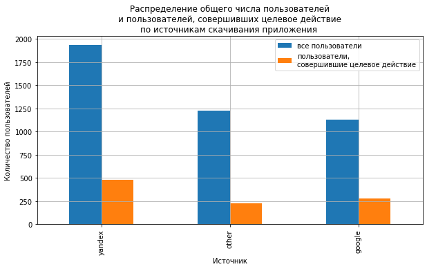

| source | total_users | target_users | %_target_in_source | %_source_in_all_users | %_target_in_all_target |
| --- | --- | --- | --- | --- | --- |
| yandex | 1934 | 478 | 24.72 | 45.05 | 48.73 |
| other | 1230 | 228 | 18.54 | 28.65 | 23.24 |
| google | 1129 | 275 | 24.36 | 26.30 | 28.03 |

```python
users_by_source = (
    profiles
    .groupby('source')
    .agg({'user_id':'count', 'event_target' :[ 'sum', 'mean']})
    .droplevel(1, axis=1)
    .reset_index()
)
users_by_source.columns = ['source', 'total_users', 'target_users', '%_target_in_source']
users_by_source['%_source_in_all_users'] =(
   round(users_by_source['total_users'] / users_by_source['total_users'].sum() *100, 2)
)

users_by_source['%_target_in_all_target'] =(
   round(users_by_source['target_users'] / users_by_source['target_users'].sum() *100, 2)
)

users_by_source['%_target_in_source'] =(
   round(users_by_source['%_target_in_source'] *100, 2)
)
users_by_source = users_by_source.sort_values(by='source', ascending=False)
users_by_source = users_by_source.set_index('source')

print(
    '\nВсего приложение установили {} пользователей,'.format(users_by_source['total_users'].sum()),
    '\nиз них целевое действие совершили {} пользователей, что составляет {} % от всех пользователей'
    .format(
        users_by_source['target_users'].sum(),
        round(users_by_source['target_users'].sum() / users_by_source['total_users'].sum() * 100, 2)
    )
)

(users_by_source[['total_users', 'target_users']]
 .sort_values(by='total_users', ascending=False).plot(kind='bar', figsize=(10,5), grid=True)
)
plt.title(
    'Распределение общего числа пользователей\nи пользователей, совершивших целевое действие\nпо источникам скачивания приложения '
)
plt.legend([
    'все пользователи',
    'пользователи,\nсовершившие целевое действие'
])
plt.ylabel('Количество пользователей')
plt.xlabel('Источник')
plt.show()

users_by_source
```

Выделено два основных источника загрузки приложения - `yandex` и `google`. Остальные источники объединены в `other`. Самый популярный источник скачивания приложения - `yandex`, через него приложение скачали 45% новых пользователей. Также через `yandex` устанавливает приложение наибольшее число пользователей, совершивших целевое действие (49% всех пользователей, совершивших целевое действие.). Упользователей из источника `other` самая низкая конверсия в целевое действие.

**Привлечение новых пользователей по времени**

Построим график привлечения новых пользователей по дням в зависимости от источника, а также график, отражающий долю привлеченных целевых пользователей по источнику за день.

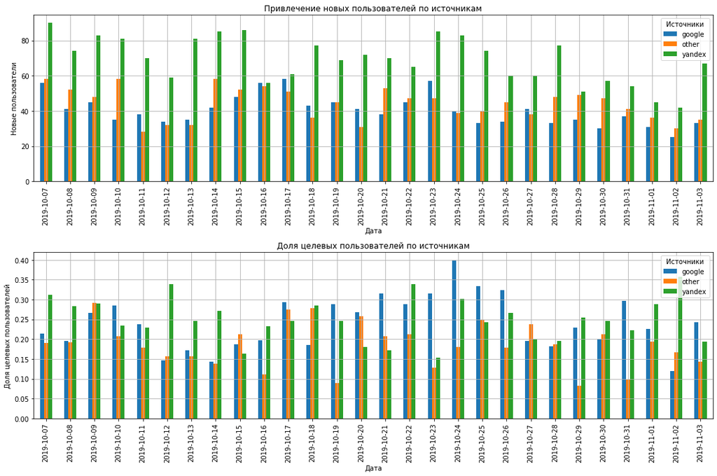

| source | users_per_day min | users_per_day max | users_per_day mean | %_tagert_users_per_day min | %_tagert_users_per_day max | %_tagert_users_per_day mean |
| --- | --- | --- | --- | --- | --- | --- |
| google | 25 | 58 | 40 | 0.12 | 0.40 | 0.24 |
| other | 28 | 58 | 44 | 0.08 | 0.29 | 0.19 |
| yandex | 42 | 90 | 69 | 0.15 | 0.36 | 0.25 |

```python
plt.subplots(figsize=(15,10))

(profiles
 .pivot_table(index='dt', columns='source', values='user_id', aggfunc='count')
 .plot(kind='bar',ax=plt.subplot(2,1,1), grid=True)
)
plt.title('Привлечение новых пользователей по источникам')
plt.legend(title='Источники')
plt.ylabel('Новые пользователи')
plt.xlabel('Дата')

(profiles
 #.query('event_target == True')
 .pivot_table(index='dt', columns='source', values='event_target', aggfunc='mean')
 .plot(kind='bar',ax=plt.subplot(2,1,2), grid=True)
)
plt.title('Доля целевых пользователей по источникам')
plt.legend(title='Источники')
plt.ylabel('Доля целевых пользователей')
plt.xlabel('Дата')

plt.tight_layout()
plt.show()


source_dt = (
    profiles.groupby(['source', 'dt'])
    .agg({'user_id': 'count', 'event_target' : 'mean'})
    .reset_index()
    .groupby('source')
    .agg({'user_id' : ['min', 'max', 'mean'], 'event_target' : ['min', 'max', 'mean']})
)
source_dt = source_dt.rename(columns={'user_id':'users_per_day', 'event_target':'%_tagert_users_per_day'})
source_dt['%_tagert_users_per_day'] = round(source_dt['%_tagert_users_per_day'], 2)
source_dt['users_per_day'] = round(source_dt['users_per_day'], 0).astype(int)
source_dt
```

Большая часть новых пользователей стабильно скачивает приложение через `yandex`, но к концу периода разница между источниками заметно сокращается, также мы видим, что в последнюю неделю периода число привлеченных пользователей заметно сократилось по всем источникам.

Что касается доли привлеченных целевых пользователей, стоит обратить внимание на период с 19 по 26 октября. В этот период доля целевых пользователей заметно выше, особенно среди пользователей установивших приложение через `google` (24 октября этот показатель достигает 40%). Возможно проводилась какая-то рекламная компания, и хоть она не увеличила общие показатели скачивания приложения, но помогла получить более качественных пользователей.

**Удержание пользователей и конверсия в целевое событие**

**Общие показатели удержания**

Посмотрим на общие показатели удержания и конверсии. Поскольку у нас данные за 4 недели - горизонт анализ зададим 7 дней.

```python
observation_date =datetime(2019,11, 3).date()  # момент анализа
horizon_days = 7  # горизонт анализа
```

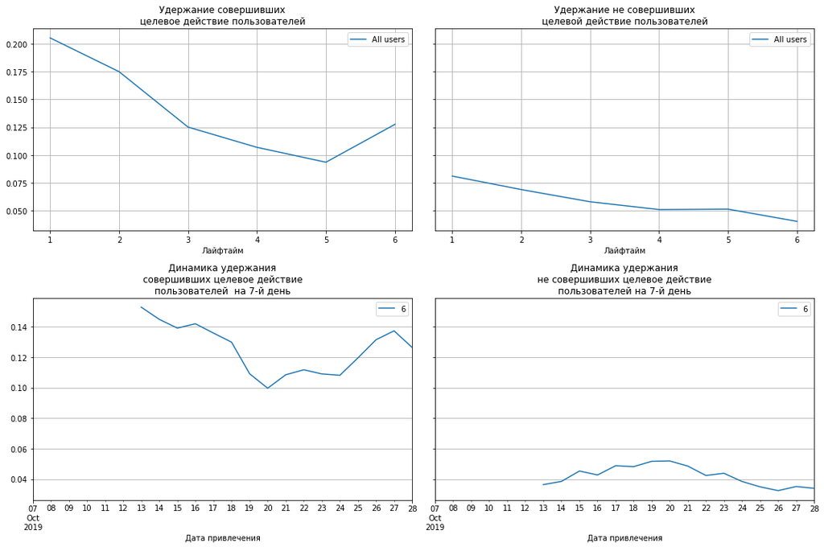

```python
retention_raw, retention_grouped, retention_history = get_retention(
    profiles, df_events, observation_date, horizon_days, dimensions=[]
)

plot_retention(retention_grouped, retention_history, horizon_days)
```

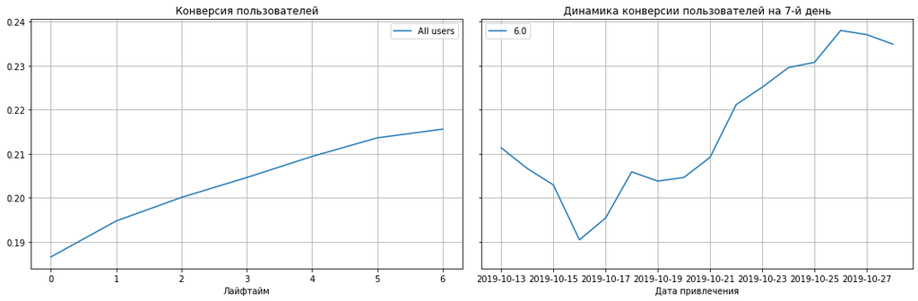

```python
conversion_raw, conversion_grouped, conversion_history = get_conversion(
    profiles, df_target, observation_date, horizon_days, dimensions=[]
)

plot_conversion(conversion_grouped, conversion_history, horizon_days)
```

Судя по общим графикам за период исследования конверсия пользователей на 7 день выросла с 21% до 23.5%.

Средний процент удержания платящих пользователей 7 дня около 12.5. Этот показатель уменьшился в течении периода (у первых когорт он около 14.5%).

**Посмотрим на удержание и конверсию в зависимости от источника**

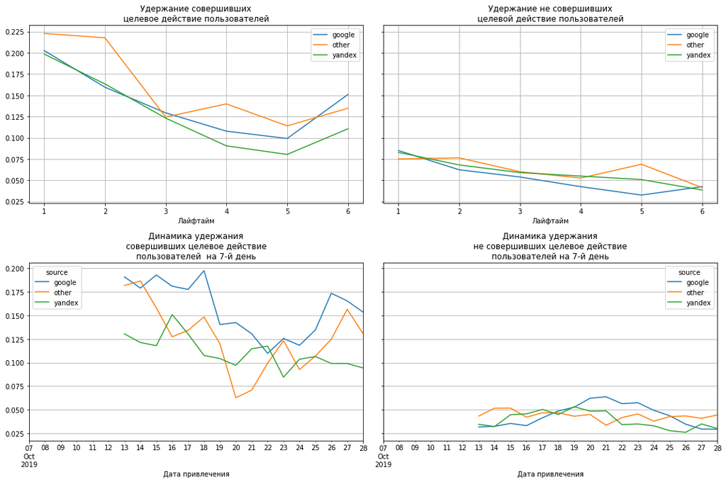

```python
retention_raw, retention_grouped, retention_history = get_retention(
    profiles, df_events, observation_date, horizon_days, dimensions=['source']
)

plot_retention(retention_grouped, retention_history, horizon_days)
```

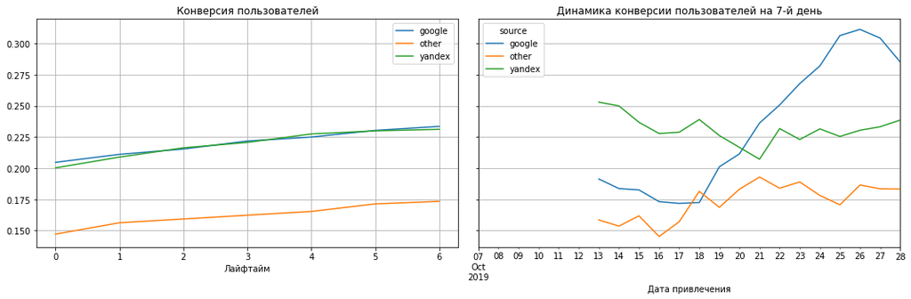

```python
conversion_raw, conversion_grouped, conversion_history = get_conversion(
    profiles, df_target, observation_date, horizon_days, dimensions=['source']
)

plot_conversion(conversion_grouped, conversion_history, horizon_days)
```

Самые низкое удержание пользователей, совершивших целевое действие, на 7-й день по источнику `yandex`(около 11%), у пользователей скачавших приложение через `google` среднее удержание 7-го дня 15%. Показатели удержания 7-го дня целевых пользователей уменьшелись по всем источникам за период исследования.

Средняя конверсия 7-го дня у пользователей `yandex` и `google` около 23%, конверсия пользователей из других источников значительно меньше 17.5%.

За период исследования наблюдается значительный рост конверсии пользователей `google`(с 19% у первых когорт, до 28% у более поздних). Также выросла конверсия пользователей из других источников (с 16 до 18%). Конверсия пользователей `yandex` несколько сократилась с 25% до 23%.

**Вывод**

Для исследования нам предоставили даннные за 4 недели с с 2019-10-07 по 2019-11-03.

За этот период в приложение пришло 4293 пользователей, из них целевое действие совершили 981 пользователей, что составляет 22.85 % от всех пользователей.

Есть два основных источника скачивания приложения:

```
- google
- yandex
- прочие источники обозначены others.
```

Основной источник - yandex, через него в приложение пришло 45% всех новых пользователей и 48% пользователей, совершивших целевое действие. В среднем приложение устанавливают 153 новых пользователя в день (69- через yandex, 40- googl, 44- другие источники). Конверсия в целевое событие выше у пользователей yandex - 25%, самая низкая у других источников - 19%.

Удержание пользователей:

Средний процент удержания 7-го дня пользователей, сделавших целевое событие около 12.5. Этот показатель уменьшился в течении периода (у первых когорт он около 14.5%).

По источникам самые низкое удержание пользователей, совершивших целевое действие, на 7-й день по источнику `yandex`(около 11%), `google` - 15%. Показатели удержания 7-го дня целевых пользователей уменьшелись по всем источникам за период исследования.

За период исследования наблюдается значительный рост конверсии пользователей `google`(с 19% у первых когорт, до 28% у более поздних). Конверсия пользователей `yandex` несколько сократилась с 25% до 23%.

#### События и сессии

**Количество и продолжительность сессий**

Посчитаем общее количество сессий в исследуемом периоде, количество сессий с целевым событием, посмотрим как они распределены по продолжительности.

```
Всего за исследуемый период совершено 11022 сессий
Среди них 1798 (16.31 %)с целевым действием.
Максимальная продолжительность сессии 233.63 минут.
Средняя продолжительность сессии 26.83 минут.
Медианная продолжительность сессии 18.4 минут.
```

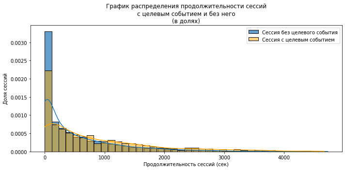

```python
print(
    '\nВсего за исследуемый период совершено {} сессий'.format(df_events['session_id'].nunique()),
    '\nСреди них {} ({} %)с целевым действием.'
    .format(
        df_events.query('event_target == True')['session_id'].nunique(),
        round(
            df_events.query('event_target == True')['session_id'].nunique()/
            df_events['session_id'].nunique() *100, 2
        )
    ),
    '\nМаксимальная продолжительность сессии {} минут.'
    .format(round((df_events['session_duration'].max()) / 60, 2)),
    '\nСредняя продолжительность сессии {} минут.'
    .format(round((df_events['session_duration'].mean()) / 60, 2)),
    '\nМедианная продолжительность сессии {} минут.'
    .format(round((df_events['session_duration'].median()) / 60, 2))
)

a_border, b_border = normal_borders(df_events, 'session_duration')

plt.subplots(figsize=(10,5))
ax = plt.subplot()
sns.histplot(
    df_events.query('event_target == False and session_duration <= @b_border')
    .groupby('session_id').agg({'session_duration':'first'}),
    x = 'session_duration',
    ax=ax,
    bins=40,
    label='Сессия без целевого события',
    alpha=0.7,
    stat='density',
    #stat='percent',
    #common_norm=False,
    kde = True
    )
sns.histplot(
    df_events.query('event_target == True and session_duration <= @b_border')
    .groupby('session_id').agg({'session_duration':'first'}),
    x = 'session_duration',
    ax=ax,
    bins=40,
    label='Сессия с целевым событием',
    alpha=0.5,
    color = 'orange',
    stat='density',
    #stat='percent',
    #common_norm=False,
    kde = True
    )
plt.title(
    f'График распределения продолжительности сессий\nс целевым событием и без него\n(в долях)'
)
plt.legend()
plt.xlabel('Продолжительность сессий (сек)')
plt.ylabel('Доля сессий')
plt.tight_layout()
```

Почти 40% сессий без целевого действия длятся до 2-х минут, среди сессий с целевым действием таких чуть больше 25%. У сессий с целевым действием доля более продолжительых больше. Среднее и медианное значение сильно сдвинуты в большую сторону из-за наличия аномально долгих по продолжительности сессий.

**Сколько сессий совершает один пользователь**

Посмотрим какое количество сессий совершли пользователи. Отличается ли количество сессий у пользователей, совершивших целевое событие.

Построим нормализированную гистограмму.

```
Пользователи, не совершившие целевое событие провели 6884 (62.46 %) сессий в приложении.
Пользователи, совершившие целевое событие провели 4138 (37.54 %) сессий в приложении.
Максимальное количество сессий одного пользователя 111 .
Среднее количество сессий одного пользователя 2.57.
Медианное количество сессий одного пользователя 1.0.
```

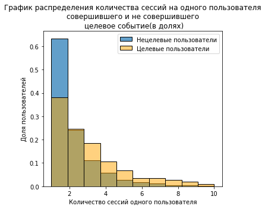

```python
users_target = profiles.query('event_target == True')['user_id']

print(
    '\nПользователи, не совершившие целевое событие провели {} ({} %) сессий в приложении.'
    .format(
        df_events.query('user_id not in @users_target')['session_id'].nunique(),
        round(
            df_events.query('user_id not in @users_target')['session_id'].nunique() /
            df_events['session_id'].nunique() * 100, 2
        )
    ),
    '\nПользователи, совершившие целевое событие провели {} ({} %) сессий в приложении.'
    .format(
        df_events.query('user_id in @users_target')['session_id'].nunique(),
        round(
            df_events.query('user_id in @users_target')['session_id'].nunique() /
            df_events['session_id'].nunique() * 100, 2
        )
    ),

    '\nМаксимальное количество сессий одного пользователя {} .'
    .format(round((df_events.groupby('user_id').agg({'session_id' :'nunique'})['session_id'].max()) , 2)),
    '\nСреднее количество сессий одного пользователя {}.'
    .format(round((df_events.groupby('user_id').agg({'session_id' :'nunique'})['session_id'].mean()) , 2)),
    '\nМедианное количество сессий одного пользователя {}.'
    .format(round((df_events.groupby('user_id').agg({'session_id' :'nunique'})['session_id'].median()) , 2))
)

a_border, b_border = normal_borders(
    df_events.groupby('user_id').agg({'session_id':'nunique'}), 'session_id'
)


plt.subplots(figsize=(5,5))
ax = plt.subplot()
sns.histplot(
    df_events.query('user_id not in @users_target')
    .groupby('user_id').agg({'session_id':'nunique'})
    .query('session_id <= 10'),
    x = 'session_id',
    ax=ax,
    bins=10,
    label='Нецелевые пользователи',
    alpha=0.7,
    stat='density',
    #stat='percent',
    #common_norm=False,
    #kde = True
    )
sns.histplot(
    df_events.query('user_id in @users_target')
    .groupby('user_id').agg({'session_id':'nunique'})
    .query('session_id <= 10'),
    x = 'session_id',
    ax=ax,
    bins=10,
    label='Целевые пользователи',
    alpha=0.5,
    color = 'orange',
    stat='density',
    #stat='percent',
    #common_norm=False,
    #kde = True
    )
plt.title(
    f'График распределения количества сессий на одного пользователя\nсовершившего и не совершившего\n целевое событие(в долях)'
)
plt.legend()
plt.xlabel('Количество сессий одного пользователя')
plt.ylabel('Доля пользователей')
plt.tight_layout()
```

Большая часть пользователей совершает в приложении 1-3 сессии. Почти 60% пользователей, не совершивших целевое событие провели только 1 сессию в приложении, у совершивших таких около 35%, среде них больше пользователей с 3 и более сессиями.

**Распределение сессий по количеству событий**

Посчитаем сколько событий совершили пользователи в приложении. Сколько событий приходится на сессии с целевым действием.

Для анализа различий в количестве событий сессий с целевым событием и без него построим нормализированную гистограмму.

```
Всего пользователи совершили в приложении 74197 событий.
В сессиях с целевым событем совершено 16311 (21.98 %) событий.
Максимальное количество событий на 1 сессию 139 .
Среднее количество событий на 1 сессию 6.73.
Медианное количество событий на 1 сессию 4.0.
```

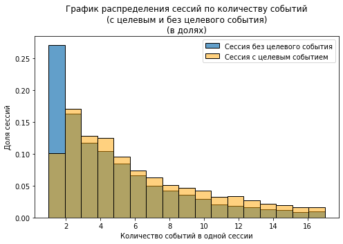

```python
users_target = profiles.query('event_target == True')['user_id']

print(
    '\nВсего пользователи совершили в приложении {} событий.'
    .format(df_events['event_time'].count()),
    '\nВ сессиях с целевым событем совершено {} ({} %) событий.'
    .format(
        df_events.query('event_target == True')['event_time'].count(),
        round(
            df_events.query('event_target == True')['event_time'].count() /
            df_events['event_time'].count() * 100, 2
        )
    ),

    '\nМаксимальное количество событий на 1 сессию {} .'
    .format(df_events.groupby('session_id').agg({'event_time':'count'})['event_time'].max()),
    '\nСреднее количество событий на 1 сессию {}.'
     .format(round( df_events.groupby('session_id').agg({'event_time':'count'})['event_time'].mean(), 2)),
    '\nМедианное количество событий на 1 сессию {}.'
    .format(round( df_events.groupby('session_id').agg({'event_time':'count'})['event_time'].median(), 2))
)

a_border, b_border = normal_borders(
    df_events.groupby('session_id').agg({'event_time':'count'}), 'event_time'
)


plt.subplots(figsize=(7,5))
ax = plt.subplot()
sns.histplot(
    df_events.query('event_target == False')
    .groupby('session_id').agg({'event_time':'count'})
    .query('event_time <= @b_border'),
    x = 'event_time',
    ax=ax,
    bins=17,
    label='Сессия без целевого события',
    alpha=0.7,
    stat='density',
    #stat='percent',
    #common_norm=False,
    #kde = True
    )
sns.histplot(
    df_events.query('event_target == True')
    .groupby('session_id').agg({'event_time':'count'})
    .query('event_time <= @b_border'),
    x = 'event_time',
    ax=ax,
    bins=17,
    label='Сессия с целевым событием',
    alpha=0.5,
    color = 'orange',
    stat='density',
    #stat='percent',
    #common_norm=False,
    #kde = True
    )
plt.title(
    f'График распределения сессий по количеству событий\n(с целевым и без целевого события)\n(в долях)'
)
plt.legend()
plt.xlabel('Количество cобытий в одной сессии')
plt.ylabel('Доля сессий')
plt.tight_layout()
```

Сессии без целевого события отличаются меньшим количеством событий, среди них почти 25% с одним событием. Среди сессий с целевым событием таких менее 10%. Получается, что чуть меньше 10% пользователей совершивших целевое действие, сделали это сразу зайдя в приложение. Возможно, это был переход по рекламной ссылке сразу к нужному объявлению. Большая часть сессий пользователей совершивших целевое событие состоит из 2-4 событий.

**Динамика сессий в приложении**

Посмотрим, как изменяется количество сессий в приложении в течении периода. Меняется ли доля сессий с целевым событием.

```
Всего за 4 недели в приложении проведено 11022 сессий.
Сессий без целевого события 9224.
Сессий с целевым событием 1798 (16.31 %).
В среднем за день пользователи проводят в приложении 394 сессий.
В том числе в среднем 64 сессий содержат целевое событие
```

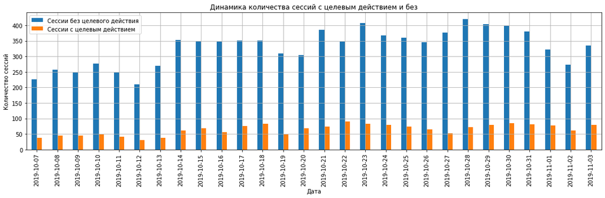

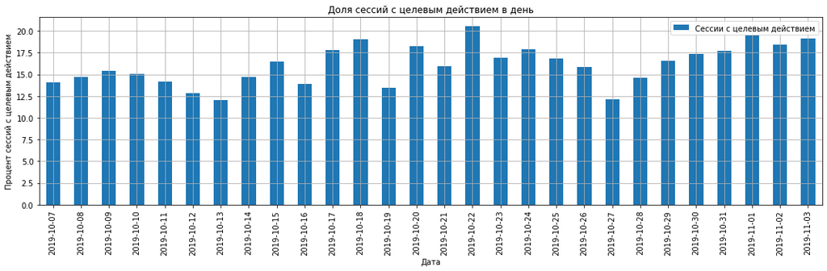

```python
sessions_per_day = (
    df_events
    .pivot_table(index='event_date', columns='event_target', values='session_id', aggfunc='nunique')
    #.droplevel(1)
)

sessions_per_day.columns.name=''
sessions_per_day = sessions_per_day.reset_index()
sessions_per_day.columns = ['date', 'no_target', 'target']
sessions_per_day['%_session_target'] =(
    round(sessions_per_day['target'] / (sessions_per_day['target'] + sessions_per_day['no_target']) * 100, 2)
)
sessions_per_day = sessions_per_day.set_index('date')

print(
    '\nВсего за 4 недели в приложении проведено {} сессий.'
    .format(
        (sessions_per_day['target'].sum() + sessions_per_day['no_target'].sum())
    ),

    '\nСессий без целевого события {}.'
    .format(
        sessions_per_day['no_target'].sum()
    ),
    '\nСессий с целевым событием {} ({} %).'
   .format(
       sessions_per_day['target'].sum(),
       round(
           sessions_per_day['target'].sum() /
           (sessions_per_day['target'].sum() + sessions_per_day['no_target'].sum()) * 100, 2
       )
   ),
    '\nВ среднем за день пользователи проводят в приложении {} сессий.'
    .format(
        round(
           (sessions_per_day['target'].sum() + sessions_per_day['no_target'].sum()) /
            sessions_per_day['no_target'].count(), 0
       ).astype('int')
    ),
    '\nВ том числе в среднем {} сессий содержат целевое событие'
    .format(
        round(
           sessions_per_day['target'].sum() /
            sessions_per_day['target'].count(), 0
       ).astype('int')
    )
)


(sessions_per_day[['no_target', 'target']]
 .plot(kind='bar',figsize=(15, 5), grid=True)
)
plt.title('Динамика количества сессий с целевым действием и без')
plt.legend(['Сессии без целевого действия', 'Сессии с целевым действием'])
plt.ylabel('Количество сессий')
plt.xlabel('Дата')
plt.tight_layout()
plt.show()

(sessions_per_day['%_session_target']
 .plot(kind='bar',figsize=(15, 5), grid=True)
)
plt.title('Доля сессий с целевым действием в день')
plt.legend(['Сессии с целевым действием'])
plt.ylabel('Процент сессий с целевым действием')
plt.xlabel('Дата')
plt.tight_layout()
plt.show()
```

**Вывод**

Всего за исследуемый период пользователи совершили в приложении 11022 сессии.Из них 1798 (16.31 %) с целевым действием. Почти 40% сессий без целевого действия длятся 2 минуты и меньше, среди сессий с целевым действием таких 25%. В целом большая часть сессий по продолжительности не превышает 10 минут. Среди сессий с целевым действием чаще встречаются более продолжительные.

Пользователи, не совершившие целевое событие провели 6884 (62.46 %) сессий в приложении. Пользователи, совершившие целевое событие провели 4138 (37.54 %) сессий в приложении.Среднее количество сессий одного пользователя 2.57.

Но почти 60% пользователей, не совершивших целевое событие провели только 1 сессию в приложении, среди тех, кто совершил целевое событие таких сессий окло 35%. Для пользователей, совершивших целевое деййствие характерны 2-4 сессий в приложении, для несовершивших -1-2.

Всего пользователи совершили в приложении 74197 событий. В сессиях с целевым событем совершено 16311 (21.98 %) событий. Медианное количество событий в сессии - 4. В сессиях без целевого события приобладают сессии с 1 событием (их около 25%), около 10% таких сессий есть и среди целевых. Для сессий с целевым событем характерно большее количество шагов (2-5).

### Анализ поведения пользователей.

**События пользователей, совершивших и не совершивших целевое действие.**

Посмотрим какие события совершают в приложении пользователи совершившие и не совершившие целевое событие. Ести ли различия в их действиях.

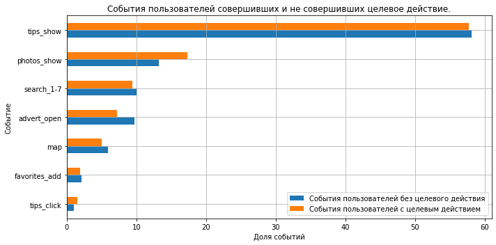

| event_name | target | no_target | %_in_target | %_in_no_target |
| --- | --- | --- | --- | --- |
| tips_show | 12768 | 27287 | 57.70 | 58.06 |
| photos_show | 3828 | 6184 | 17.30 | 13.16 |
| search_1-7 | 2084 | 4700 | 9.42 | 10.00 |
| advert_open | 1589 | 4575 | 7.18 | 9.73 |
| map | 1101 | 2780 | 4.98 | 5.91 |
| favorites_add | 424 | 993 | 1.92 | 2.11 |
| tips_click | 333 | 481 | 1.50 | 1.02 |

```python
users_target = profiles.query('event_target == True')['user_id']

event_by_users_target = (
    df_events.query('user_id in @users_target and event_name != "contacts_show" and event_name != "contacts_call"')
    .groupby('event_name')
    .agg({'event_time' : 'count'})
    .reset_index()
    .rename(columns={'event_time' : 'total_events'})
)

event_by_users_no_target = (
    df_events.query('user_id not in @users_target')
    .groupby('event_name')
    .agg({'event_time' : 'count'})
    .reset_index()
)

events_by_users =(
    event_by_users_target.merge(event_by_users_no_target, on='event_name', how='left' )
    .rename(columns={'total_events': 'target', 'event_time' : 'no_target'})
    .set_index('event_name')
)
events_by_users['%_in_target'] = (
    round(events_by_users['target'] / events_by_users['target'].sum() * 100, 2)
)
events_by_users['%_in_no_target'] = (
    round(events_by_users['no_target'] / events_by_users['no_target'].sum() * 100, 2)
)

(events_by_users[['%_in_no_target', '%_in_target']]
 .sort_values(by='%_in_target')
 .plot(kind='barh',figsize=(10, 5), grid=True)
)
plt.title('События пользователей совершивших и не совершивших целевое действие.')
plt.legend(['События пользователей без целевого действия', 'События пользователей с целевым действием'])
plt.ylabel('Событие')
plt.xlabel('Доля событий')
plt.tight_layout()
plt.show()

events_by_users.sort_values(by='%_in_target', ascending=False)
```

Пользователи, совершающие целевое действие немного чаще смотрят фотографии и кликают на рекомендованные объявления. При этом доля остальных событий у них меньше. Особенно событие `advert_open` его доля в событиях таких пользователей 7%, а у пользователей не совершавших целевого действия доля таких событий 10%.

**События в сессиях с целевым событием и без него**

Для исследования нам важны действия пользователей. Событие `tips_show` - происходит автоматически, не по выбору пользователей, поэтому посмотрим на сессии без учета этого события.

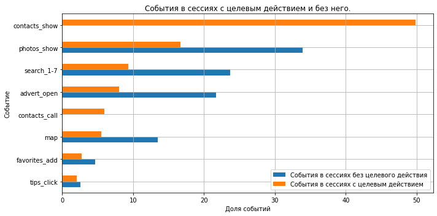

| event_name | no_target | target | %_in_no_target | %_in_target |
| --- | --- | --- | --- | --- |
| contacts_show | NaN | 4529.0 | NaN | 49.82 |
| photos_show | 8493.0 | 1519.0 | 33.90 | 16.71 |
| search_1-7 | 5938.0 | 846.0 | 23.70 | 9.31 |
| advert_open | 5435.0 | 729.0 | 21.70 | 8.02 |
| contacts_call | NaN | 541.0 | NaN | 5.95 |
| map | 3382.0 | 499.0 | 13.50 | 5.49 |
| favorites_add | 1171.0 | 246.0 | 4.67 | 2.71 |
| tips_click | 632.0 | 182.0 | 2.52 | 2.00 |

```python
events_by_session = (
    df_events.query('event_name != "tips_show"')
    .pivot_table(index='event_name', columns='event_target', values='event_time', aggfunc='count')
)
events_by_session.columns = ['no_target', 'target']

events_by_session['%_in_no_target'] = (
    round(events_by_session['no_target'] / events_by_session['no_target'].sum() * 100, 2)
)

events_by_session['%_in_target'] = (
    round(events_by_session['target'] / events_by_session['target'].sum() * 100, 2)
)

(events_by_session[['%_in_no_target', '%_in_target']]
 .sort_values(by='%_in_target')
 .plot(kind='barh',figsize=(10, 5), grid=True)
)
plt.title('События в сессиях с целевым действием и без него.')
plt.legend(['События в сессиях без целевого действия', 'События в сессиях с целевым действием'])
plt.ylabel('Событие')
plt.xlabel('Доля событий')
plt.tight_layout()
plt.show()

events_by_session.sort_values(by='%_in_target', ascending=False)
```

В сессиях с целевым действием самое популярное событие само целевое действия - почти 50% событий таких сессий. Остальные события распределены очень похоже с сессиями без целевых действий. Самый популярный шаг (если не учитывать целевой) в обоих сессиях `photos_show`, затем идут события поиска. Реже всего пользователи во всех сессиях совершают действия `tips_click`.

**Посмотрим какое событие предшествует целевому**

Определим предшествующий целевому событию шаг, без учета события `tips_show`

```python
df_events_target = df_events.query('event_target == True and event_name != "tips_show"')
df_events_target['pre_event'] = df_events_target['event_name'].shift()

df_events_target.loc[df_events_target['session_id'] != df_events_target['session_id'].shift(), 'pre_event'] =(
    'first_event'
)

df_events_target.head(10)
```

|  | event_time | event_name | user_id | event_date | event_weekday | event_week | session_id | start_time | end_time | session_duration | pre_event | pre_event_dur | event_target |
| --- | --- | --- | --- | --- | --- | --- | --- | --- | --- | --- | --- | --- | --- |
| 60 | 2019-10-07 11:28:52.489988 | contacts_show | 057a4dc6-0698-4662-ba56-64f2bc6e0adc | 2019-10-07 | 0 | 41 | 7 | 2019-10-07 11:28:52.489988 | 2019-10-07 11:29:20.308054 | 27.0 | first_event | 0.0 | True |
| 291 | 2019-10-07 21:38:02.944592 | contacts_show | 136b7b37-2bd4-4718-b14a-e38bc3d6d112 | 2019-10-07 | 0 | 41 | 22 | 2019-10-07 21:33:19.333950 | 2019-10-07 21:38:02.944592 | 283.0 | first_event | 247.0 | True |
| 297 | 2019-10-07 20:26:29.099318 | contacts_show | 145009b0-bb47-4239-8afb-ad9a4b21ee2f | 2019-10-07 | 0 | 41 | 24 | 2019-10-07 20:26:29.099318 | 2019-10-07 20:50:25.549394 | 1436.0 | first_event | 0.0 | True |
| 302 | 2019-10-07 20:37:57.598909 | tips_click | 145009b0-bb47-4239-8afb-ad9a4b21ee2f | 2019-10-07 | 0 | 41 | 24 | 2019-10-07 20:26:29.099318 | 2019-10-07 20:50:25.549394 | 1436.0 | contacts_show | 115.0 | True |
| 406 | 2019-10-07 10:19:49.080484 | contacts_show | 1a3361d1-2002-4389-a669-ecb06ea7a90a | 2019-10-07 | 0 | 41 | 34 | 2019-10-07 10:18:55.701270 | 2019-10-07 10:23:15.108748 | 259.0 | first_event | 53.0 | True |
| 434 | 2019-10-07 13:17:03.296722 | photos_show | 1daa906e-cf82-4e9c-a408-ce1730d4b64e | 2019-10-07 | 0 | 41 | 37 | 2019-10-07 13:17:03.296722 | 2019-10-07 13:38:41.806006 | 1298.0 | first_event | 0.0 | True |
| 435 | 2019-10-07 13:17:36.096663 | photos_show | 1daa906e-cf82-4e9c-a408-ce1730d4b64e | 2019-10-07 | 0 | 41 | 37 | 2019-10-07 13:17:03.296722 | 2019-10-07 13:38:41.806006 | 1298.0 | photos_show | 32.0 | True |
| 436 | 2019-10-07 13:19:37.387196 | photos_show | 1daa906e-cf82-4e9c-a408-ce1730d4b64e | 2019-10-07 | 0 | 41 | 37 | 2019-10-07 13:17:03.296722 | 2019-10-07 13:38:41.806006 | 1298.0 | photos_show | 121.0 | True |
| 437 | 2019-10-07 13:19:59.922973 | contacts_show | 1daa906e-cf82-4e9c-a408-ce1730d4b64e | 2019-10-07 | 0 | 41 | 37 | 2019-10-07 13:17:03.296722 | 2019-10-07 13:38:41.806006 | 1298.0 | photos_show | 22.0 | True |
| 438 | 2019-10-07 13:20:02.378109 | contacts_call | 1daa906e-cf82-4e9c-a408-ce1730d4b64e | 2019-10-07 | 0 | 41 | 37 | 2019-10-07 13:17:03.296722 | 2019-10-07 13:38:41.806006 | 1298.0 | contacts_show | 2.0 | True |

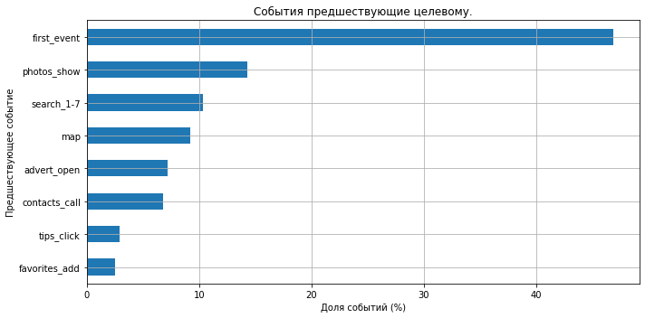

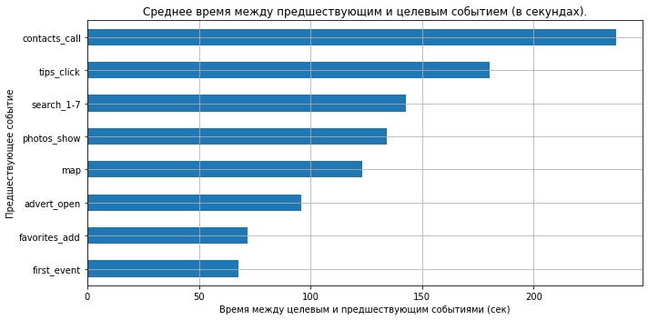

| pre_event | pre_event_number | pre_event_time | %_in_pre_event |
| --- | --- | --- | --- |
| first_event | 1061 | 67.651272 | 46.84 |
| photos_show | 324 | 134.092593 | 14.30 |
| search_1-7 | 234 | 142.816239 | 10.33 |
| map | 208 | 123.408654 | 9.18 |
| advert_open | 163 | 95.693252 | 7.20 |
| contacts_call | 153 | 236.849673 | 6.75 |
| tips_click | 66 | 180.242424 | 2.91 |
| favorites_add | 56 | 71.678571 | 2.47 |

```python
pre_event = (
    df_events_target.query('event_name == "contacts_show" and pre_event != "contacts_show"')
    .groupby('pre_event')
    .agg({'event_time' : 'count', 'pre_event_dur' : 'mean'})
)
pre_event.columns=['pre_event_number', 'pre_event_time']

pre_event['%_in_pre_event'] = (
    round(pre_event['pre_event_number'] / pre_event['pre_event_number'].sum() * 100, 2)
)

(pre_event['%_in_pre_event']
 .sort_values()
 .plot(kind='barh',figsize=(10, 5), grid=True)
)
plt.title('События предшествующие целевому.')
#plt.legend(['Событие'])
plt.ylabel('Предшествующее событие')
plt.xlabel('Доля событий (%)')
plt.tight_layout()
plt.show()

(pre_event['pre_event_time']
 .sort_values()
 .plot(kind='barh',figsize=(10, 5), grid=True)
)
plt.title('Среднее время между предшествующим и целевым событием (в секундах).')
#plt.legend(['Событие'])
plt.ylabel('Предшествующее событие')
plt.xlabel('Время между целевым и предшествующим событиями (сек)')
plt.tight_layout()
plt.show()

pre_event.sort_values(by='pre_event_number', ascending=False)
```

Почти в половине успешных сессий пользователи не используют дополнительные опции, а просто прокручивают ленту приложения в поисках подходящего объявления.

Посчитаем общеее количество по каждому событию, и какой процент из них предшествовал целевому шагу.

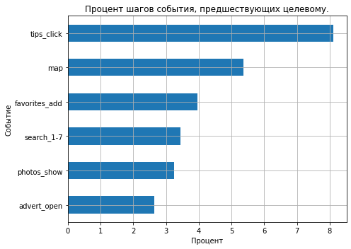

| event_name | pre_event_number | pre_event_time | %_in_pre_event | event_number | %_pre_event_in_events |
| --- | --- | --- | --- | --- | --- |
| tips_click | 66 | 180.242424 | 2.91 | 814.0 | 8.11 |
| map | 208 | 123.408654 | 9.18 | 3881.0 | 5.36 |
| favorites_add | 56 | 71.678571 | 2.47 | 1417.0 | 3.95 |
| search_1-7 | 234 | 142.816239 | 10.33 | 6784.0 | 3.45 |
| photos_show | 324 | 134.092593 | 14.30 | 10012.0 | 3.24 |
| advert_open | 163 | 95.693252 | 7.20 | 6164.0 | 2.64 |

```python
events_by_pre_event = (
    df_events.query('event_name != "contacts_show" and event_name != "tips_show"')
    .groupby('event_name')
    .agg({'event_time' : 'count'})
    .rename(columns={'event_time' : 'event_number'})
    .reset_index()
)
pre_event = pre_event.reset_index().rename(columns={'pre_event': 'event_name'})
events_by_pre_event = (
    pre_event.merge(events_by_pre_event, on='event_name', how='left')
    #.set_index('event_name')
)
events_by_pre_event['%_pre_event_in_events'] =(
    round(events_by_pre_event['pre_event_number'] / events_by_pre_event['event_number'] *100, 2)
)

events_by_pre_event = (
    events_by_pre_event.loc[
        (events_by_pre_event['event_name'] != 'contacts_call')& (events_by_pre_event['event_name'] != 'first_event')
    ].set_index('event_name')
)

(
    events_by_pre_event['%_pre_event_in_events']
    .sort_values()
    .plot(kind='barh',figsize=(7, 5), grid=True)
)
plt.title('Процент шагов события, предшествующих целевому.')
#plt.legend(['Событие'])
plt.ylabel('Событие')
plt.xlabel('Процент')
plt.tight_layout()
plt.show()

events_by_pre_event.sort_values(by='%_pre_event_in_events', ascending=False)
```

Самая высокая доля шагов, приводящих к целевому действию у события `tips_click` -8.11%, на втором месте событие `map` - 5% таких шагов предшествовали целевому событию. Реже всего к целевому действию приводит `advert_open` (всего по 2.6% этих шагов предшествовали целевому событию).

**События по пользователям**

Посмотрим сколько пользователей совершили те или иные шаги не зависимо от результата.

```python
events_by_users = (
    df_events.groupby('event_name')
    .agg({'user_id':'nunique'})
    .sort_values(by='user_id', ascending=False)
    .rename(columns={'user_id':'users_number'})
)
events_by_users['%_in_total_users'] = (
    round(events_by_users['users_number'] / df_events['user_id'].nunique() *100, 2)
)
events_by_users
```

| event_name | users_number | %_in_total_users |
| --- | --- | --- |
| tips_show | 2801 | 65.25 |
| search_1-7 | 1666 | 38.81 |
| map | 1456 | 33.92 |
| photos_show | 1095 | 25.51 |
| contacts_show | 981 | 22.85 |
| advert_open | 751 | 17.49 |
| favorites_add | 351 | 8.18 |
| tips_click | 322 | 7.50 |
| contacts_call | 213 | 4.96 |

Чаще всего пользователи дополнительно пользуются функцией поиска (39% всех пользователей) и просмотра карты объявлений (34%). Фотографии смотрели 25.5% всех пользователей.

Интересно, что рекомендованные объявления были показаны лишь 65% пользователей.

Посмотрим на события группы пользователей, которым показывали рекомендованные объявления и нет.

```
Всего сессий с событием "tips_show" - 6960
Всего сессий без события "tips_show" - 4062
```

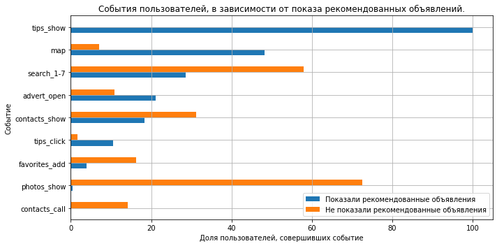

```
События пользователей, которым показали рекомендации
```

| event_name | events_with_tips_show | %_in_events_tips | users_tips_show | %_in_users_tips |
| --- | --- | --- | --- | --- |
| tips_show | 40055 | 71.11 | 2801 | 100.00 |
| map | 3695 | 6.56 | 1352 | 48.27 |
| search_1-7 | 3029 | 5.38 | 801 | 28.60 |
| advert_open | 5071 | 9.00 | 590 | 21.06 |
| contacts_show | 2827 | 5.02 | 516 | 18.42 |
| tips_click | 701 | 1.24 | 297 | 10.60 |
| favorites_add | 597 | 1.06 | 108 | 3.86 |
| photos_show | 351 | 0.62 | 13 | 0.46 |
| contacts_call | 1 | 0.00 | 1 | 0.04 |

```
События пользователей, которым не показали рекомендации
```

| event_name | events_no_tips_show | %_in_events_no_tips | users_no_tips_show | %_in_users_no_tips |
| --- | --- | --- | --- | --- |
| photos_show | 9661.0 | 54.06 | 1082.0 | 72.52 |
| search_1-7 | 3755.0 | 21.01 | 865.0 | 57.98 |
| contacts_show | 1702.0 | 9.52 | 465.0 | 31.17 |
| favorites_add | 820.0 | 4.59 | 243.0 | 16.29 |
| contacts_call | 540.0 | 3.02 | 212.0 | 14.21 |
| advert_open | 1093.0 | 6.12 | 161.0 | 10.79 |
| map | 186.0 | 1.04 | 104.0 | 6.97 |
| tips_click | 113.0 | 0.63 | 25.0 | 1.68 |
| tips_show | NaN | NaN | NaN | NaN |

```python
list_tips_show = df_events.query('event_name == "tips_show"')['user_id'].unique()
sessions_tips_show = (
    df_events.query('user_id in @list_tips_show')
    .groupby('event_name')
    .agg({'event_time' : 'count', 'user_id' :'nunique'})
    .reset_index()
    .rename(columns={'event_time' : 'events_with_tips_show', 'user_id' : 'users_tips_show'})
)

sessions_no_tips_show = (
    df_events.query('user_id not in @list_tips_show')
    .groupby('event_name')
    .agg({'event_time' : 'count', 'user_id' :'nunique'})
    .reset_index()
    .rename(columns={'event_time' : 'events_no_tips_show', 'user_id' : 'users_no_tips_show'})
)

sessions_on_tips_show =(
    sessions_tips_show.merge(sessions_no_tips_show, on='event_name', how='outer' )
    .set_index('event_name')
)
sessions_on_tips_show['%_in_events_tips'] = (
    round(sessions_on_tips_show['events_with_tips_show']
          / sessions_on_tips_show['events_with_tips_show'].sum() * 100, 2)
)
sessions_on_tips_show['%_in_events_no_tips'] = (
    round(sessions_on_tips_show['events_no_tips_show'] /
          sessions_on_tips_show['events_no_tips_show'].sum() * 100, 2)
)

sessions_on_tips_show['%_in_users_tips'] = (
    round(sessions_on_tips_show['users_tips_show']
          / len(list_tips_show) * 100, 2)
)

sessions_on_tips_show['%_in_users_no_tips'] = (
    round(sessions_on_tips_show['users_no_tips_show']
          / (df_events.query('user_id not in @list_tips_show')['user_id'].nunique()) * 100, 2)
)

print(
    'Всего сессий с событием "tips_show" - {}'
    .format(df_events.query('user_id in @list_tips_show')['session_id'].nunique()
    )
)

print(
    'Всего сессий без события "tips_show" - {}'
    .format(df_events.query('user_id not in @list_tips_show')['session_id'].nunique()
    )
)

(sessions_on_tips_show[['%_in_users_tips', '%_in_users_no_tips']]
 .sort_values(by='%_in_users_tips')
 .plot(kind='barh',figsize=(10, 5), grid=True)
)
plt.title('События пользователей, в зависимости от показа рекомендованных объявлений.')
plt.legend(['Показали рекомендованные объявления', 'Не показали рекомендованные объявления'])
plt.ylabel('Событие')
plt.xlabel('Доля пользователей, совершивших событие')
plt.tight_layout()
plt.show()

print ('\nСобытия пользователей, которым показали рекомендации')

display(
    sessions_on_tips_show[['events_with_tips_show', '%_in_events_tips', 'users_tips_show', '%_in_users_tips']]
    .sort_values(by='%_in_users_tips', ascending=False)
)

print ('\nСобытия пользователей, которым не показали рекомендации')

(
    sessions_on_tips_show[['events_no_tips_show', '%_in_events_no_tips', 'users_no_tips_show', '%_in_users_no_tips']]
    .sort_values(by='%_in_users_no_tips', ascending=False)
)
```

События сессий этих двух групп отличаются. Пользователи, которым показаны рекомендации практически не смотрят фотографии (всего 0.5% пользователей), из действий предпочитают просмотр карты объявлений. Пользователи, которым не показали рекомендации в основном смотрят фотографии объявлений (72.5%) и осуществляют события поиска (58%). Также можно заметить, что у пользователей смотревших рекомендации доля совершивших целевое событие меньше (18%, у не смотревших - 31%).

Интересно, что при отсутствии показа рекомендаций, у второй группы пользователей есть событие `tips_click` (1.7% пользователей делали этот шаг).

Обычно рекомендованные объявления показывают всем пользователям по-умолчанию. В нашем случае могут быть разные причины отсутствия рекомендаций в сессиях. Возможно у пользователей установлены разные версии приложения. Либо это техническая проблема и в таблицы для исследования по какой-то причине не выгрузились события `tips_show` для второй группы пользователей.

**Вывод**

Основные события в приложении, которые осуществляет большинство пользователей это - поиск (39% пользователей делали этот шаг), просмотр карты объявлений (34%), просмотр фотографий (25.5%).

Что касается событий, предшествующих целевому, то в 47% целевых сессий - целевое событие первый шаг пользователя. (возможно переход по рекламной ссылке), в 14 % случаев в контакты пользователи переходят из прсмотра фотографий, 10% - из поиска. Также есть переходы из события "contacts_call" (возможно возврат к контактам, по которым был звонок).

Между самыми популярными событиями перед переходом к целевому (просмотр фотографий и поиск) в среднем проходит около 2-х минут.

Согласно данным предоставленной таблицы, рекомендованные объявления видят только 65% пользователей. И события смотревших рекомендации пользователей отличаются от тех, кому их не показали:

  Но в целом не ясно почему не все пользователи видят рекомендации - специальные ли это настройки приложения, разные версии или упущения при выгрузке данных.

## Проверка гипотез

### Гипотеза: Конверсии в целевое событие групп совершивших событие `tips_show` и `tips_click` и только `tips_show` различаются.

Одни пользователи совершают действия `tips_show` и `tips_click` , другие — только `tips_show` . Проверим гипотезу: конверсия в просмотры контактов различается у этих двух групп.

Предварительно посмотрим конверсию пользователей в зависимости от совершения ими шагов `tips_show` и `tips_click`

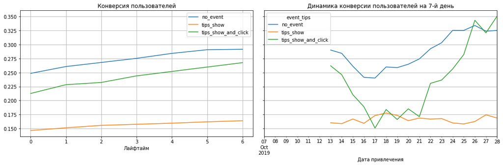

```python
conversion_raw, conversion_grouped, conversion_history = get_conversion(
    profiles, df_target, observation_date, horizon_days, dimensions=['event_tips']
)

plot_conversion(conversion_grouped, conversion_history, horizon_days)
```

Средняя конверсия 7-го дня у пользователей совершивших действия `tips_show` и `tips_click` значительно выше чем у пользователей совершивших только `tips_show` (27 и 16% соответственно). Если смотреть на показатели в динамике, то за период исследования конверсия пользователей с действием `tips_show` остается примерно на одном уровне. Конверсия пользователей с действиями `tips_show` и `tips_click` не стабильна. На графики видно, ее резкое падение для когорт до 21 октября (для когорт 17-21 октября показатели конверсии сравниваемых групп примерно на одном уровне). Затем конверсия `tips_show` и `tips_click` начинает расти и у последних когорт достигает 35%.

Также можно отметить, что более высокие показатели конверсии за весь период у пользователей, которые вообще не совершали этих действий.

**Статистическая проверка гипотезы**

Посчитаем количество пользователей и пользователей, совершивших целевое событие для каждой группы

```python
tips_show = (
    df_target.loc[df_target['user_id']
                  .isin(profiles.query('event_tips == "tips_show"')['user_id'].unique())]
    .groupby('event_name')
    .agg({'user_id':'nunique'})
    .rename(columns={'user_id':'successes1'})
)

tips_show_and_click = (
    df_target.loc[df_target['user_id']
                  .isin(profiles.query('event_tips == "tips_show_and_click"')['user_id'].unique())]
    .groupby('event_name')
    .agg({'user_id':'nunique'})
    .rename(columns={'user_id':'successes2'})
)

tips_show['trials1'] = profiles.query('event_tips == "tips_show"')['user_id'].nunique()
tips_show_and_click['trials2'] = profiles.query('event_tips == "tips_show_and_click"')['user_id'].nunique()
print('Группа "tips_show"')
display(tips_show)
print('\nГруппа "tips_show_and_click"')
tips_show_and_click
```

```
Группа "tips_show"
```

| event_name | successes1 | trials1 |
| --- | --- | --- |
| contacts_show | 425 | 2504 |

```
Группа "tips_show_and_click"
```

| event_name | successes2 | trials2 |
| --- | --- | --- |
| contacts_show | 91 | 297 |

**Сформулируем нулевую и альтернативную гипотезы**

**Нулевая гипотеза** - Конверсии в целевое событие двух генеральных совокупностей пользователeй совершаюoщих действия `tips_show` и `tips_click` и пользователей совершающих только `tips_show` равны.

**Альтернативная гипотеза** - Конверсии в целевое событие двух генеральных совокупностей пользователeй совершаюoщих действия `tips_show` и `tips_click` и пользователей совершающих только `tips_show` различаются.

Определим уровень статистической значимости `alpha` для сравнения двух групп **0,01** Применим функцию для расчета статистической значимости.

```python
alpha = 0.01

p_value = check_hypothesise(
    tips_show.loc['contacts_show','successes1'],
    tips_show_and_click.loc['contacts_show','successes2'],
    tips_show.loc['contacts_show','trials1'],
    tips_show_and_click.loc['contacts_show','trials2']
)
if p_value < alpha:
    print(
        f'Отвергаем нулевую гипотезу: \nмежду долями по целевому событию в группах есть значимая разница\n',
        'p_value=', p_value,3
    )
else:
    print(
        f'\nНе получилось отвергнуть нулевую гипотезу,\nнет оснований считать доли групп по целевому событию разными\n',
        'p_value=', p_value, 3,'\n'
    )
```

```
Отвергаем нулевую гипотезу:
между долями по целевому событию в группах есть значимая разница
 p_value= 9.218316554537864e-09 3
```

**Вывод**

Вероятность того, что различий в конверсиях между группами `tips_show` и `tips_show_and_click` нет почти нулевая. Значит у нас есть основания отвергнуть нулевую гипотезу и не отвергать альтернативную.

### Гипотеза: Конверсия в просмотры контактов различается у групп, совершавших действие `photos_show` и не совершавших.

Одни пользователи совершают действие `photos_show`, другие нет. Проверим гипотезу: конверсия в просмотры контактов различается у этих двух групп.

Посмотрим на показатели конверсии по группам.

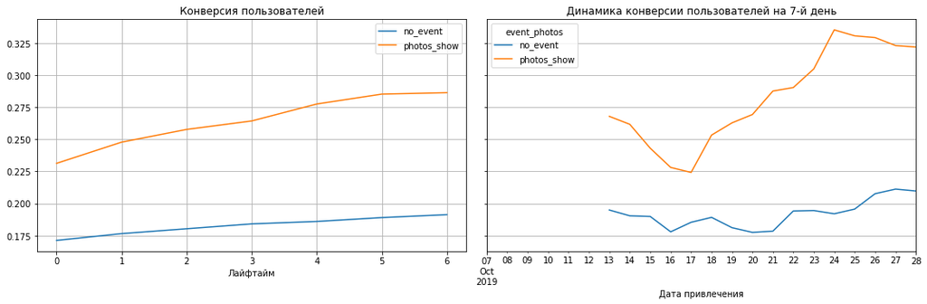

```python
conversion_raw, conversion_grouped, conversion_history = get_conversion(
    profiles, df_target, observation_date, horizon_days, dimensions=['event_photos']
)

plot_conversion(conversion_grouped, conversion_history, horizon_days)
```

По данным из выборки средняя конверсия 7-го дня в целевое событие у пользователей сделавших шаг `photos_show` почти 29%, а у группы не сделавшей этот шаг всего 19%. В динамике показатели обеих групп растут, но конверсия группы `photos_show` значительно больше весь период наблюдений.

**Статистическая проверка гипотезы**

Посчитамем размеры групп и количество пользователей, совершивших целевое событие в каждой группе.

```python
photos_show = (
    df_target.loc[df_target['user_id']
                  .isin(profiles.query('event_photos == "photos_show"')['user_id'].unique())]
    .groupby('event_name')
    .agg({'user_id':'nunique'})
    .rename(columns={'user_id':'successes1'})
)

no_event = (
    df_target.loc[df_target['user_id']
                  .isin(profiles.query('event_photos == "no_event"')['user_id'].unique())]
    .groupby('event_name')
    .agg({'user_id':'nunique'})
    .rename(columns={'user_id':'successes2'})
)

photos_show['trials1'] = profiles.query('event_photos == "photos_show"')['user_id'].nunique()
no_event['trials2'] = profiles.query('event_photos == "no_event"')['user_id'].nunique()
print('Группа "photos_show"')
display(photos_show)
print('\nГруппа "no_event"')
no_event
```

```
Группа "photos_show"
```

| event_name | successes1 | trials1 |
| --- | --- | --- |
| contacts_show | 339 | 1095 |

```
Группа "no_event"
```

| event_name | successes2 | trials2 |
| --- | --- | --- |
| contacts_show | 642 | 3198 |

**Сформулируем нулевую и альтернативную гипотезы**

**Нулевая гипотеза** - Конверсии в целевое событие двух генеральных совокупностей пользователeй совершаюoщих действия `photos_show` и пользователей не совершавшюих это действие - равны.

**Альтернативная гипотеза** - Конверсии в целевое событие двух генеральных совокупностей пользователeй совершаюoщих действие `photos_show` и пользователей не совершающих его различаются.

Определим уровень статистической значимости `alpha` для сравнения двух групп **0,01** Применим функцию для расчета статистической значимости.

```python
alpha = 0.01

p_value = check_hypothesise(
    photos_show.loc['contacts_show','successes1'],
    no_event.loc['contacts_show','successes2'],
    photos_show.loc['contacts_show','trials1'],
    no_event.loc['contacts_show','trials2']
)
if p_value < alpha:
    print(
        f'Отвергаем нулевую гипотезу: \nмежду долями по целевому событию в группах есть значимая разница\n',
        'p_value=', p_value,3
    )
else:
    print(
        f'\nНе получилось отвергнуть нулевую гипотезу,\nнет оснований считать доли групп по целевому событию разными\n',
        'p_value=', p_value, 3,'\n'
    )
```

```
Отвергаем нулевую гипотезу:
между долями по целевому событию в группах есть значимая разница
 p_value= 1.3278267374516872e-13 3
```

**Вывод**

Проверка z-тестом подтвердила наличие статистически значимой разницы в конверсиях двух групп. Вероятность того, что конверсии групп `photos_show` и `no_event` одинаковы меньше статистически значимой (почти нулевая). Мы можем отвергнуть нулевую гипотезу и не отвергать альтернативную.

## Общие выводы и рекомендации

Основными источниками скачивания приложения являются "yandex" и "google", остальные источники объединены в группу "other". Пользователи предпочитают скачивать приложение через "yandex" (45%). У пользователей скачавших приложение через "yandex" самая высокая конверсия в целевое действие - 24.7%. В целом целевое событие совершили 22.9% пользователей в исследуемом периоде. Однако в динамике можно увидеть, что конверсия пользователей "yandex" сокращается к концу периода, а пользователей "google" растет.

В день приложение скачивает в среднем 153 новых пользователя. Средний процент удержания целевых пользователей 7-го дня - около 12.5%

Пользователи, не совершившие целевое событие в основном проводят в приложении только 1 сессию (таких 60%). Для совершивших целевое событие 1 сессия характерна в 35% случаев, они чаще проводят 2-3 сессии в приложении.

Медианное количество событий в одной сессии - 4. У пользователей без целевого действия 25% сессий с 1 событием. Также среди сессий с целевым событием 10% содержат только один шаг (т.е. целевое событие). Возможно это переходы по рекламным ссылкам.

Чаще всего пользователи совершают события поиска (39% пользователей делают этот шаг), просмотр карты объявлений (характерен для 34% пользователей) и фотографии смотрят 25.5% пользователей.

**Рекомендации**